# Patient Selection for Diabetes Drug Testing

1. Project Instructions & Prerequisites
2. Learning Objectives
3. Data Preparation
4. Create Categorical Features with TF Feature Columns
5. Create Continuous/Numerical Features with TF Feature Columns
6. Build Deep Learning Regression Model with Sequential API and TF Probability Layers
7. Evaluating Potential Model Biases with Aequitas Toolkit

# 1. Project Instructions & Prerequisites

## Project Instructions

**Context**: EHR data is becoming a key source of real-world evidence (RWE) for the pharmaceutical industry and regulators to [make decisions on clinical trials](https://www.fda.gov/news-events/speeches-fda-officials/breaking-down-barriers-between-clinical-trials-and-clinical-care-incorporating-real-world-evidence). You are a data scientist for an exciting unicorn healthcare startup that has created a groundbreaking diabetes drug that is ready for clinical trial testing. It is a very unique and sensitive drug that requires administering the drug over at least 5-7 days of time in the hospital with frequent monitoring/testing and patient medication adherence training with a mobile application. You have been provided a patient dataset from a client partner and are tasked with building a predictive model that can identify which type of patients the company should focus their efforts testing this drug on. Target patients are people that are likely to be in the hospital for this duration of time and will not incur significant additional costs for administering this drug to the patient and monitoring.

In order to achieve your goal you must build a regression model that can predict the estimated hospitalization time for a patient and use this to select/filter patients for your study.

**Expected Hospitalization Time Regression Model:** Utilizing a synthetic dataset(denormalized at the line level augmentation) built off of the UCI Diabetes readmission dataset, students will build a regression model that predicts the expected days of hospitalization time and then convert this to a binary prediction of whether to include or exclude that patient from the clinical trial.

This project will demonstrate the importance of building the right data representation at the encounter level, with appropriate filtering and preprocessing/feature engineering of key medical code sets. This project will also require students to analyze and interpret their model for biases across key demographic groups.

## Dataset

Due to healthcare PHI regulations (HIPAA, HITECH), there are limited number of publicly available datasets and some datasets require training and approval. So, for the purpose of this exercise, we are using a dataset from [UC Irvine](https://archive.ics.uci.edu/ml/datasets/Diabetes+130-US+hospitals+for+years+1999-2008) that has been modified for this course. Please note that it is limited in its representation of some key features such as diagnosis codes which are usually an unordered list in 835s/837s (the HL7 standard interchange formats used for claims and remits).

**Data Schema:** The dataset reference information can be found [here](https://github.com/udacity/nd320-c1-emr-data-starter/blob/master/project/data_schema_references/). There are two CSVs that provide more details on the fields and some of the mapped values.

# 2. Learning Objectives

By the end of the project, you will be able to

- Use the Tensorflow Dataset API to scalably extract, transform, and load datasets and build datasets aggregated at the line, encounter, and patient data levels(longitudinal)
- Analyze EHR datasets to check for common issues (data leakage, statistical properties, missing values, high cardinality) by performing exploratory data analysis.
- Create categorical features from Key Industry Code Sets (ICD, CPT, NDC) and reduce dimensionality for high cardinality features by using embeddings
- Create derived features(bucketing, cross-features, embeddings) utilizing Tensorflow feature columns on both continuous and categorical input features
- SWBAT use the Tensorflow Probability library to train a model that provides uncertainty range predictions that allow for risk adjustment/prioritization and triaging of predictions
- Analyze and determine biases for a model for key demographic groups by evaluating performance metrics across groups by using the Aequitas framework

# 3. Data Preparation

```python
# from __future__ import absolute_import, division, print_function, unicode_literals
import os
import numpy as np
import tensorflow as tf
from tensorflow.keras import layers
import tensorflow_probability as tfp
import matplotlib.pyplot as plt
import pandas as pd
import aequitas as ae

# Put all of the helper functions in utils
from utils import build_vocab_files, show_group_stats_viz, aggregate_dataset, preprocess_df, df_to_dataset, posterior_mean_field, prior_trainable
pd.set_option('display.max_columns', 500)
from student_utils import *
# this allows you to make changes and save in student_utils.py and the file is reloaded every time you run a code block
%load_ext autoreload
%autoreload
```

```python
#OPEN ISSUE ON MAC OSX for TF model training
import os
os.environ['KMP_DUPLICATE_LIB_OK']='True'
```

```python
# Aequitas
from aequitas.preprocessing import preprocess_input_df
from aequitas.group import Group
from aequitas.plotting import Plot
from aequitas.bias import Bias
from aequitas.fairness import Fairness
```

```python
import warnings
warnings.filterwarnings("ignore")

import functools

%matplotlib inline
import matplotlib.pyplot as plt
plt.rcParams["figure.figsize"] = (16,12)
import seaborn as sns
sns.set(style="darkgrid")

from PIL import Image
import IPython.display as display

from sklearn.model_selection import train_test_split
from sklearn.metrics import f1_score, classification_report, roc_auc_score, precision_score, recall_score, roc_curve, precision_recall_curve, confusion_matrix
from keras.callbacks import ModelCheckpoint, EarlyStopping
```

```python
# For reproducible results
# https://stackoverflow.com/questions/50659482/why-cant-i-get-reproducible-results-in-keras-even-though-i-set-the-random-seeds)

# Seed value
seed_value= 42

# 1. Set `PYTHONHASHSEED` environment variable at a fixed value
import os
os.environ['PYTHONHASHSEED']=str(seed_value)

# 2. Set `python` built-in pseudo-random generator at a fixed value
import random
random.seed(seed_value)

# 3. Set `numpy` pseudo-random generator at a fixed value
import numpy as np
np.random.seed(seed_value)

# 4. Set the `tensorflow` pseudo-random generator at a fixed value
import tensorflow as tf
tf.random.set_seed(seed_value)
# for later versions:
# tf.compat.v1.set_random_seed(seed_value)
```

## Check on the folder structure

```python
!ls -l
```

```
total 2876
-rw-r--r-- 1 root root   38795 Dec 31 16:25  baseline-auc-plot.png
-rw-r--r-- 1 root root   29524 Dec 31 02:03  baseline-history-plot.png
-rw-r--r-- 1 root root   33056 Dec 31 16:25  baseline-pr-plot.png
drwxr-xr-x 3 root root    4096 May 11  2020  data
drwxr-xr-x 2 root root    4096 Nov 29 11:54  diabetes_vocab
-rw-r--r-- 1 root root       0 Mar 11  2020  __init__.py
drwxr-xr-x 2 root root    4096 Mar 11  2020  medication_lookup_tables
drwxr-xr-x 2 root root    4096 Dec 31 15:43  __pycache__
-rw-r--r-- 1 root root   25270 Dec 31 15:02  sequential_3d-history-plot.png
-rw-r--r-- 1 root root   29708 Dec 31 02:05  sequential_3n-history-plot.png
-rw-r--r-- 1 root root   39361 Dec 31 16:33  sequential_3rd-auc-plot.png
-rw-r--r-- 1 root root   25367 Dec 31 15:10  sequential_3rd-history-plot.png
-rw-r--r-- 1 root root   32984 Dec 31 16:33  sequential_3rd-pr-plot.png
-rw-r--r-- 1 root root   40146 Dec 31 16:33  sequential_4rd-auc-plot.png
-rw-r--r-- 1 root root   24996 Dec 31 15:31  sequential_4rd-history-plot.png
-rw-r--r-- 1 root root   33125 Dec 31 16:33  sequential_4rd-pr-plot.png
-rw-r--r-- 1 root root   24957 Dec 31 02:10  sequential_4r-history-plot.png
-rw-r--r-- 1 root root   38745 Dec 31 16:26  sequential_5d-auc-plot.png
-rw-r--r-- 1 root root   29021 Dec 31 15:15  sequential_5d-history-plot.png
-rw-r--r-- 1 root root   33147 Dec 31 16:26  sequential_5d-pr-plot.png
-rw-r--r-- 1 root root   29485 Dec 31 02:13  sequential_5n-history-plot.png
-rw-r--r-- 1 root root   37616 Dec 31 01:36  sequential_5r-auc-plot.png
-rw-r--r-- 1 root root   25280 Dec 31 15:20  sequential_5rd-history-plot.png
-rw-r--r-- 1 root root   24779 Dec 31 14:57  sequential_5r-history-plot.png
-rw-r--r-- 1 root root   33140 Dec 31 01:36  sequential_5r-pr-plot.png
-rw-r--r-- 1 root root   38771 Dec 31 16:26  sequential_6r-auc-plot.png
-rw-r--r-- 1 root root   40230 Dec 31 16:06  sequential_6rd-auc-plot.png
-rw-r--r-- 1 root root   25021 Dec 31 15:27  sequential_6rd-history-plot.png
-rw-r--r-- 1 root root   33024 Dec 31 16:06  sequential_6rd-pr-plot.png
-rw-r--r-- 1 root root   22797 Dec 31 02:47  sequential_6r-history-plot.png
-rw-r--r-- 1 root root   33180 Dec 31 16:26  sequential_6r-pr-plot.png
-rw-r--r-- 1 root root   38791 Dec 31 01:58  sequential_7r-auc-plot.png
-rw-r--r-- 1 root root   23905 Dec 31 02:40  sequential_7r-history-plot.png
-rw-r--r-- 1 root root   25059 Dec 31 01:58  sequential_7r-pr-plot.png
-rw-r--r-- 1 root root 1611716 Dec 31 12:49  student_project-Copy1.ipynb
-rw-r--r-- 1 root root   86596 Dec 31 16:34  student_project.ipynb
-rw-r--r-- 1 root root    7412 Dec 31 15:43  student_utils.py
-rw-r--r-- 1 root root   31099 Dec 10 17:48 '<tensorflow.python.keras.engine.sequential.Sequential object at 0x7f2ce31e7a90>-history-plot.png'
-rw-r--r-- 1 root root   28272 Dec 29 17:25 '<tensorflow.python.keras.engine.sequential.Sequential object at 0x7f68cbd4d410>-history-plot.png'
-rw-r--r-- 1 root root   27459 Dec 29 17:08 '<tensorflow.python.keras.engine.sequential.Sequential object at 0x7f68cbd52990>-history-plot.png'
-rw-r--r-- 1 root root   26907 Dec 29 17:26 '<tensorflow.python.keras.engine.sequential.Sequential object at 0x7f68cc813850>-history-plot.png'
-rw-r--r-- 1 root root   23582 Dec 29 16:48 '<tensorflow.python.keras.engine.sequential.Sequential object at 0x7f68d0504e50>-history-plot.png'
-rw-r--r-- 1 root root   25117 Dec 29 16:50 '<tensorflow.python.keras.engine.sequential.Sequential object at 0x7f68d16505d0>-history-plot.png'
-rw-r--r-- 1 root root   28225 Dec 29 15:43 '<tensorflow.python.keras.engine.sequential.Sequential object at 0x7f68dbc47910>-history-plot.png'
-rw-r--r-- 1 root root    4375 May 11  2020  utils.py
drwxr-xr-x 3 root root    4096 Dec 31 15:31  weights
```

```python
!ls -l data
```

```
total 16756
-rw-r--r-- 1 root root 17131611 Mar 11  2020 final_project_dataset.csv
```

```python
!ls -l medication_lookup_tables
```

```
total 32
-rw-r--r-- 1 root root 30360 Mar 11  2020 final_ndc_lookup_table
```

## Dataset Loading and Schema Review

Load the dataset and view a sample of the dataset along with reviewing the schema reference files to gain a deeper understanding of the dataset. The dataset is located at the following path:

- `https://github.com/udacity/nd320-c1-emr-data-starter/blob/master/project/starter_code/data/final_project_dataset.csv`

Also, review the information found in the data schema [here](https://github.com/udacity/nd320-c1-emr-data-starter/blob/master/project/data_schema_references/).

```python
dataset_path = "./data/final_project_dataset.csv"
df = pd.read_csv(dataset_path)
df.shape
```

```
(143424, 26)
```

```python
df.head()
```

|  | encounter_id | patient_nbr | race | gender | age | weight | admission_type_id | discharge_disposition_id | admission_source_id | time_in_hospital | payer_code | medical_specialty | primary_diagnosis_code | other_diagnosis_codes | number_outpatient | number_inpatient | number_emergency | num_lab_procedures | number_diagnoses | num_medications | num_procedures | ndc_code | max_glu_serum | A1Cresult | change | readmitted |
| --- | --- | --- | --- | --- | --- | --- | --- | --- | --- | --- | --- | --- | --- | --- | --- | --- | --- | --- | --- | --- | --- | --- | --- | --- | --- | --- |
| 0 | 2278392 | 8222157 | Caucasian | Female | [0-10) | ? | 6 | 25 | 1 | 1 | ? | Pediatrics-Endocrinology | 250.83 | ?\|? | 0 | 0 | 0 | 41 | 1 | 1 | 0 | NaN | None | None | No | NO |
| 1 | 149190 | 55629189 | Caucasian | Female | [10-20) | ? | 1 | 1 | 7 | 3 | ? | ? | 276 | 250.01\|255 | 0 | 0 | 0 | 59 | 9 | 18 | 0 | 68071-1701 | None | None | Ch | >30 |
| 2 | 64410 | 86047875 | AfricanAmerican | Female | [20-30) | ? | 1 | 1 | 7 | 2 | ? | ? | 648 | 250\|V27 | 2 | 1 | 0 | 11 | 6 | 13 | 5 | 0378-1110 | None | None | No | NO |
| 3 | 500364 | 82442376 | Caucasian | Male | [30-40) | ? | 1 | 1 | 7 | 2 | ? | ? | 8 | 250.43\|403 | 0 | 0 | 0 | 44 | 7 | 16 | 1 | 68071-1701 | None | None | Ch | NO |
| 4 | 16680 | 42519267 | Caucasian | Male | [40-50) | ? | 1 | 1 | 7 | 1 | ? | ? | 197 | 157\|250 | 0 | 0 | 0 | 51 | 5 | 8 | 0 | 0049-4110 | None | None | Ch | NO |

## Determine Level of Dataset (Line or Encounter)

Based off of analysis of the data, what level is this dataset? Is it at the line or encounter level? Are there any key fields besides the `encounter_id` and `patient_nbr` fields that we should use to aggregate on? Knowing this information will help inform us what level of aggregation is necessary for future steps and is a step that is often overlooked.

With EHR datasets, there are three levels:

- **Line Level**: A denormalized or disaggregated representation of all the things that might happen in a medical visit or encounter.
- **Encounter Level**: Also known as the visit level, which is the aggregated information from the previously mentioned line level for one encounter. This information can be collapsed into a single row or arrays.
- **Longitudinal Level**: Also known as the patient level view. This level aggregates the patient history and can show how the culmination of visits/encounter lead to some clinical impact.

Using the wrong EHR dataset level can lead to major errors with building models because data preparation is done with faulty assumptions and lead to serious error. For example, a common cause is the duplication of encounter information when you take a line-level dataset and treat it as an encounter level dataset.

If the total number of rows is greater than the number of unique encounters, it is at the line level.

```python
try:
    assert len(df) > df['encounter_id'].nunique()
    print("Line")
except:
    print("Not Line")
```

```
Line
```

If the total number of rows is equal to the number of unique encounters, it is at the encounter level.

```python
try:
    assert len(df) == df['encounter_id'].nunique()
    print("Encounter")
except:
    print("Not Encounter")
```

```
Not Encounter
```

For the longitudinal or patient level, you will see multiple encounters grouped under a patient and you might not even see the encounter id field since this information is collapsed/aggregated under a unique patient id. In this case, the total number of rows should equal the total number of unique patients.

```python
try:
    assert len(df) == df['patient_nbr'].nunique()
    print("Longitudinal")
except:
    print("Not Longitudinal")
```

```
Not Longitudinal
```

It seems that our data is at the **line level**, i.e. a denormalized or disaggregated representation of all the things that might happen in a medical visit or encounter.

To aggregate line level to encounter level, we could use the fields:

## Analyze Dataset

- Field(s) with high amount of missing/zero values
- Which numerical field(s) has/have a Gaussian(normal) distribution shape?
- Which field(s) have high cardinality and why (HINT: ndc_code is one feature)
- Please describe the demographic distributions in the dataset for the age and gender fields.

**OPTIONAL**: Use the Tensorflow Data Validation and Analysis library to complete.

- The [Tensorflow Data Validation and Analysis library](https://www.tensorflow.org/tfx/data_validation/get_started) is a useful tool for analyzing and summarizing dataset statistics. It is especially useful because it can scale to large datasets that do not fit into memory.
- Note that there are some bugs that are still being resolved with Chrome v80 and we have moved away from using this for the project.

### Which fields have high amount of missing/zero values?

Before we count missing/zero values, we should check whether any placeholders represent missing numbers.

```python
for col in df.select_dtypes(include=['category', 'object']).columns:
    print(col)
    print(df[col].unique())
    print()
```

```
race
['Caucasian' 'AfricanAmerican' '?' 'Other' 'Asian' 'Hispanic']

gender
['Female' 'Male' 'Unknown/Invalid']

age
['[0-10)' '[10-20)' '[20-30)' '[30-40)' '[40-50)' '[50-60)' '[60-70)'
 '[70-80)' '[80-90)' '[90-100)']

weight
['?' '[75-100)' '[50-75)' '[0-25)' '[100-125)' '[25-50)' '[125-150)'
 '[175-200)' '[150-175)' '>200']

payer_code
['?' 'MC' 'MD' 'HM' 'UN' 'BC' 'SP' 'CP' 'SI' 'DM' 'CM' 'CH' 'PO' 'WC' 'OT'
 'OG' 'MP' 'FR']

medical_specialty
['Pediatrics-Endocrinology' '?' 'InternalMedicine'
 'Family/GeneralPractice' 'Cardiology' 'Surgery-General' 'Orthopedics'
 'Gastroenterology' 'Surgery-Cardiovascular/Thoracic' 'Nephrology'
 'Orthopedics-Reconstructive' 'Psychiatry' 'Emergency/Trauma'
 'Pulmonology' 'Surgery-Neuro' 'Obsterics&Gynecology-GynecologicOnco'
 'ObstetricsandGynecology' 'Pediatrics' 'Hematology/Oncology'
 'Otolaryngology' 'Surgery-Colon&Rectal' 'Pediatrics-CriticalCare'
 'Endocrinology' 'Urology' 'Psychiatry-Child/Adolescent'
 'Pediatrics-Pulmonology' 'Neurology' 'Anesthesiology-Pediatric'
 'Radiology' 'Pediatrics-Hematology-Oncology' 'Psychology' 'Podiatry'
 'Gynecology' 'Oncology' 'Pediatrics-Neurology' 'Surgery-Plastic'
 'Surgery-Thoracic' 'Surgery-PlasticwithinHeadandNeck' 'Ophthalmology'
 'Surgery-Pediatric' 'Pediatrics-EmergencyMedicine'
 'PhysicalMedicineandRehabilitation' 'InfectiousDiseases' 'Anesthesiology'
 'Rheumatology' 'AllergyandImmunology' 'Surgery-Maxillofacial'
 'Pediatrics-InfectiousDiseases' 'Pediatrics-AllergyandImmunology'
 'Dentistry' 'Surgeon' 'Surgery-Vascular' 'Osteopath'
 'Psychiatry-Addictive' 'Surgery-Cardiovascular' 'PhysicianNotFound'
 'Hematology' 'Proctology' 'Obstetrics' 'SurgicalSpecialty' 'Radiologist'
 'Pathology' 'Dermatology' 'SportsMedicine' 'Speech' 'Hospitalist'
 'OutreachServices' 'Cardiology-Pediatric' 'Perinatology'
```

[output cut: 108 more lines]

```
 '57664-685' '0093-7456' '0009-5014' '42291-305' '42571-105' '76333-127'
 '51991-854' '0093-7457' '0228-2752' '0093-7455' '60429-485' '23155-115'
 '0179-0205' '49884-984' '64764-302' '0781-5635' '33342-177' '43063-699']

max_glu_serum
['None' '>300' 'Norm' '>200']

A1Cresult
['None' '>7' '>8' 'Norm']

change
['No' 'Ch']

readmitted
['NO' '>30' '<30']
```

The following seem to be string placeholders:

- `?`
- `?|?`
- `Unknown/Invalid`
- `None`

```python
df.select_dtypes(include=['float', 'int']).describe(include='all').T
```

|  | count | mean | std | min | 25% | 50% | 75% | max |
| --- | --- | --- | --- | --- | --- | --- | --- | --- |
| encounter_id | 143424.0 | 1.674290e+08 | 1.019046e+08 | 12522.0 | 88295964.0 | 154763706.0 | 232089688.5 | 443867222.0 |
| patient_nbr | 143424.0 | 5.493608e+07 | 3.857840e+07 | 135.0 | 23572188.0 | 46307830.5 | 88236270.0 | 189502619.0 |
| admission_type_id | 143424.0 | 2.027694e+00 | 1.427585e+00 | 1.0 | 1.0 | 1.0 | 3.0 | 8.0 |
| discharge_disposition_id | 143424.0 | 3.655316e+00 | 5.219279e+00 | 1.0 | 1.0 | 1.0 | 3.0 | 28.0 |
| admission_source_id | 143424.0 | 5.701096e+00 | 4.064532e+00 | 1.0 | 1.0 | 7.0 | 7.0 | 25.0 |
| time_in_hospital | 143424.0 | 4.490190e+00 | 2.999667e+00 | 1.0 | 2.0 | 4.0 | 6.0 | 14.0 |
| number_outpatient | 143424.0 | 3.624289e-01 | 1.249295e+00 | 0.0 | 0.0 | 0.0 | 0.0 | 42.0 |
| number_inpatient | 143424.0 | 6.008548e-01 | 1.207934e+00 | 0.0 | 0.0 | 0.0 | 1.0 | 21.0 |
| number_emergency | 143424.0 | 1.950859e-01 | 9.204102e-01 | 0.0 | 0.0 | 0.0 | 0.0 | 76.0 |
| num_lab_procedures | 143424.0 | 4.325575e+01 | 1.965732e+01 | 1.0 | 32.0 | 44.0 | 57.0 | 132.0 |
| number_diagnoses | 143424.0 | 7.424434e+00 | 1.924872e+00 | 1.0 | 6.0 | 8.0 | 9.0 | 16.0 |
| num_medications | 143424.0 | 1.677603e+01 | 8.397130e+00 | 1.0 | 11.0 | 15.0 | 21.0 | 81.0 |
| num_procedures | 143424.0 | 1.349021e+00 | 1.719104e+00 | 0.0 | 0.0 | 1.0 | 2.0 | 6.0 |

Questionable is, whether `0` is a placeholder for a missing value, or an actual number. Columns that have `0` as a value:

- `number_outpatient`: Number of outpatient visits of the patient in the year preceding the encounter
- `number_inpatient`: Number of inpatient visits of the patient in the year preceding the encounter
- `number_emergency`: Number of emergency visits of the patient in the year preceding the encounter
- `num_procedures`: Number of procedures (other than lab tests) performed during the encounter

If we look at the data dictionary descriptions above, any of these could take on actual zero value, so we well not treat `0` in these columns as missing values.

We should also change some column types, while we are at data cleaning.

```python
df.info()
```

```
<class 'pandas.core.frame.DataFrame'>
RangeIndex: 143424 entries, 0 to 143423
Data columns (total 26 columns):
 #   Column                    Non-Null Count   Dtype
---  ------                    --------------   -----
 0   encounter_id              143424 non-null  int64
 1   patient_nbr               143424 non-null  int64
 2   race                      143424 non-null  object
 3   gender                    143424 non-null  object
 4   age                       143424 non-null  object
 5   weight                    143424 non-null  object
 6   admission_type_id         143424 non-null  int64
 7   discharge_disposition_id  143424 non-null  int64
 8   admission_source_id       143424 non-null  int64
 9   time_in_hospital          143424 non-null  int64
```

[output cut: 18 more lines]

According to the [schema](https://github.com/udacity/nd320-c1-emr-data-starter/blob/master/project/data_schema_references/), we need to change some column types.

- `weight`: numerical -- This is actually **wrong** in the schema. weight seems to be a bucketed numerical feature, same as age.
- `admission_type_id`: str/categorical
- `discharge_disposition_id`: str/categorical
- `admission_source_id`: str/categorical

```python
df[['admission_type_id', 'discharge_disposition_id', 'admission_source_id']] = df[['admission_type_id', 'discharge_disposition_id', 'admission_source_id']].astype(str)
```

**Note**: Ideally, we want to clean the data properly. While this is the correct approach in the ordinary case, for this project we are using functions provided in `utils.py`, which assume certain things about the data, and if they don't receive what is expected, these functions can produce wrong results or errors. Thus, following advice from [here](https://knowledge.udacity.com/questions/220292#_=_), data is not cleaned in order to avoid an error with a built-in function later. To be able to count the missing value, we will instead create a copy of the df.

Now we can check which columns have missing values, how many values are missing, and what % they take up from all values:

```python
df_msno = df.copy()
df_msno = df_msno.replace('?', np.nan)
df_msno = df_msno.replace('?|?', np.nan)
df_msno = df_msno.replace('Unknown/Invalid', np.nan)
df_msno = df_msno.replace('None', np.nan)
```

```python
# Missing values statistics
missing_values = missing_values_table(df_msno)
missing_values

# take into account, we didn't actually clean the missing values above to avoid running into another error below!
```

```
Your selected dataframe has 26 columns.
There are 10 columns that have missing values.
```

|  | Missing Values | % of Total Values |
| --- | --- | --- |
| weight | 139122 | 97.0 |
| max_glu_serum | 136409 | 95.1 |
| A1Cresult | 117650 | 82.0 |
| medical_specialty | 69463 | 48.4 |
| payer_code | 54190 | 37.8 |
| ndc_code | 23462 | 16.4 |
| race | 3309 | 2.3 |
| other_diagnosis_codes | 340 | 0.2 |
| primary_diagnosis_code | 33 | 0.0 |
| gender | 5 | 0.0 |

### Which numerical field(s) has/have a Gaussian (normal) distribution shape?

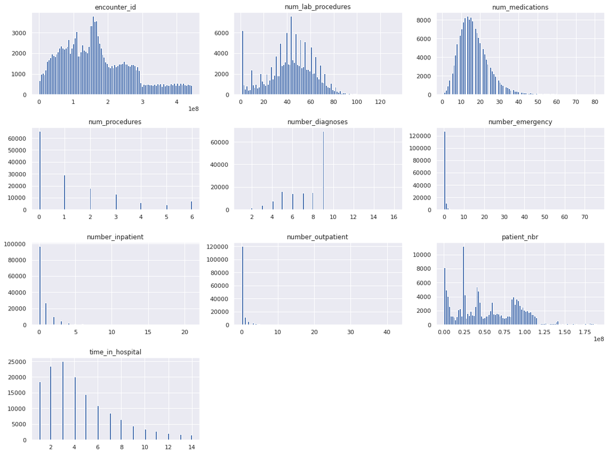

```python
df.hist(bins=100)
plt.tight_layout()
plt.show()
```

```python
df[['num_lab_procedures', 'num_medications', 'time_in_hospital']].describe().T
```

|  | count | mean | std | min | 25% | 50% | 75% | max |
| --- | --- | --- | --- | --- | --- | --- | --- | --- |
| num_lab_procedures | 143424.0 | 43.255745 | 19.657319 | 1.0 | 32.0 | 44.0 | 57.0 | 132.0 |
| num_medications | 143424.0 | 16.776035 | 8.397130 | 1.0 | 11.0 | 15.0 | 21.0 | 81.0 |
| time_in_hospital | 143424.0 | 4.490190 | 2.999667 | 1.0 | 2.0 | 4.0 | 6.0 | 14.0 |

The following numerical features seem to have a somewhat normal distribution:

- `num_lab_procedures`: mean 43.26, median 44
- `num_medications`: mean 16.78, median 15
- `time_in_hospital`: mean 4.49, median 4

### Which field(s) have high cardinality and why?

High-cardinality refers to columns with values that are very uncommon or unique. High-cardinality column values are typically identification numbers, email addresses, or user names. An example of a data table column with high-cardinality would be a USERS table with a column named USER_ID.

```python
df.select_dtypes(include=['category', 'object']).nunique().sort_values(ascending=False)
```

```
other_diagnosis_codes       19374
primary_diagnosis_code        717
ndc_code                      251
medical_specialty              73
discharge_disposition_id       26
payer_code                     18
admission_source_id            17
weight                         10
age                            10
admission_type_id               8
race                            6
A1Cresult                       4
max_glu_serum                   4
readmitted                      3
gender                          3
change                          2
dtype: int64
```

The high cardinality features consist of identifier values for different matters.

### Describe the demographic distribution for age and gender fields.

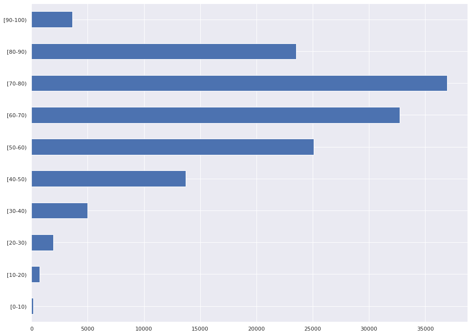

```python
df['age'].value_counts().sort_index().plot(kind='barh')
plt.show()
```

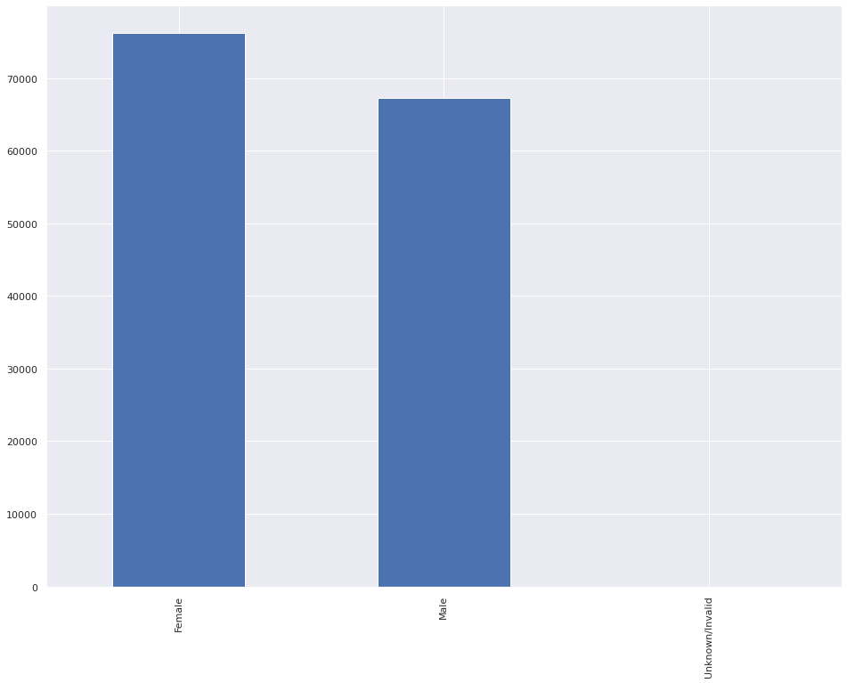

```python
df['gender'].value_counts().sort_index().plot(kind='bar')
plt.show()
```

```python
print(f'''Male \t{100*len(df[(df['gender'] == 'Male')])/len(df):.1f}%
Female \t{100*len(df[(df['gender'] == 'Female')])/len(df):.1f}%
Diff \t{100*(len(df[(df['gender'] == 'Female')]) - len(df[(df['gender'] == 'Male')]))/len(df):.1f}%''')
```

```
Male 	46.9%
Female 	53.1%
Diff 	6.2%
```

We have slightly more Female (53.1%) entries than Male (46.9%).

### Use the Tensorflow Data Validation and Analysis library

The Tensorflow Data Validation and Analysis library is a useful tool for analyzing and summarizing dataset statistics. It is especially useful because it can scale to large datasets that do not fit into memory. Note that there are some bugs that are still being resolved with Chrome v80 and **we have moved away from using this for the project.**

```python
%%capture
'''
import tensorflow_data_validation as tfdv
full_data_stats = tfdv.generate_statistics_from_csv(data_location='./data/final_project_dataset.csv')
tfdv.visualize_statistics(full_data_stats)
'''
```

## Reduce Dimensionality of the NDC Code Feature

NDC codes are a common format to represent the wide variety of drugs that are prescribed for patient care in the United States. The challenge is that there are many codes that map to the same or similar drug. You are provided with the [NDC drug lookup file](https://github.com/udacity/nd320-c1-emr-data-starter/blob/master/project/data_schema_references/ndc_lookup_table.csv) derived from the [National Drug Codes List site](https://ndclist.com/).

```python
#NDC code lookup file
ndc_code_path = "./medication_lookup_tables/final_ndc_lookup_table"
ndc_code_df = pd.read_csv(ndc_code_path)
ndc_code_df.shape
```

```
(269, 7)
```

```python
ndc_code_df.describe().T
```

|  | count | unique | top | freq |
| --- | --- | --- | --- | --- |
| NDC_Code | 269 | 267 | 0781-5634 | 2 |
| Proprietary Name | 269 | 39 | Metformin Hydrochloride | 61 |
| Non-proprietary Name | 269 | 24 | Metformin Hydrochloride | 71 |
| Dosage Form | 267 | 9 | Tablet | 159 |
| Route Name | 264 | 2 | Oral | 263 |
| Company Name | 267 | 68 | Teva Pharmaceuticals Usa, Inc. | 17 |
| Product Type | 267 | 1 | Human Prescription Drug | 267 |

```python
reduce_dim_df = pd.merge(df,
                         ndc_code_df[['Non-proprietary Name', 'NDC_Code']],
                         how='left',
                         left_on='ndc_code',
                         right_on='NDC_Code')
reduce_dim_df.drop('NDC_Code', axis=1, inplace=True)
reduce_dim_df.rename(columns={'Non-proprietary Name': 'generic_drug_name'}, inplace=True)
reduce_dim_df.shape
```

```
(143482, 27)
```

```python
reduce_dim_df.head()
```

|  | encounter_id | patient_nbr | race | gender | age | weight | admission_type_id | discharge_disposition_id | admission_source_id | time_in_hospital | payer_code | medical_specialty | primary_diagnosis_code | other_diagnosis_codes | number_outpatient | number_inpatient | number_emergency | num_lab_procedures | number_diagnoses | num_medications | num_procedures | ndc_code | max_glu_serum | A1Cresult | change | readmitted | generic_drug_name |
| --- | --- | --- | --- | --- | --- | --- | --- | --- | --- | --- | --- | --- | --- | --- | --- | --- | --- | --- | --- | --- | --- | --- | --- | --- | --- | --- | --- |
| 0 | 2278392 | 8222157 | Caucasian | Female | [0-10) | ? | 6 | 25 | 1 | 1 | ? | Pediatrics-Endocrinology | 250.83 | ?\|? | 0 | 0 | 0 | 41 | 1 | 1 | 0 | NaN | None | None | No | NO | NaN |
| 1 | 149190 | 55629189 | Caucasian | Female | [10-20) | ? | 1 | 1 | 7 | 3 | ? | ? | 276 | 250.01\|255 | 0 | 0 | 0 | 59 | 9 | 18 | 0 | 68071-1701 | None | None | Ch | >30 | Human Insulin |
| 2 | 64410 | 86047875 | AfricanAmerican | Female | [20-30) | ? | 1 | 1 | 7 | 2 | ? | ? | 648 | 250\|V27 | 2 | 1 | 0 | 11 | 6 | 13 | 5 | 0378-1110 | None | None | No | NO | Glipizide |
| 3 | 500364 | 82442376 | Caucasian | Male | [30-40) | ? | 1 | 1 | 7 | 2 | ? | ? | 8 | 250.43\|403 | 0 | 0 | 0 | 44 | 7 | 16 | 1 | 68071-1701 | None | None | Ch | NO | Human Insulin |
| 4 | 16680 | 42519267 | Caucasian | Male | [40-50) | ? | 1 | 1 | 7 | 1 | ? | ? | 197 | 157\|250 | 0 | 0 | 0 | 51 | 5 | 8 | 0 | 0049-4110 | None | None | Ch | NO | Glipizide |

```python
# Number of unique values should be less for the new output field
assert df['ndc_code'].nunique() > reduce_dim_df['generic_drug_name'].nunique()
print(f'Dimensionality reduced from {df["ndc_code"].nunique()} to {reduce_dim_df["generic_drug_name"].nunique()}')
```

[output not shown]

## Select First Encounter for each Patient

In order to simplify the aggregation of data for the model, we will only select the first encounter for each patient in the dataset. This is to reduce the risk of data leakage of future patient encounters and to reduce complexity of the data transformation and modeling steps. We will assume that sorting in numerical order on the encounter_id provides the time horizon for determining which encounters come before and after another.

```python
first_encounter_df = reduce_dim_df.sort_values(['encounter_id'], ascending=True).groupby('patient_nbr').head(1)
```

```python
# unique patients in transformed dataset
unique_patients = first_encounter_df['patient_nbr'].nunique()
print("Number of unique patients:\t{}".format(unique_patients))

# unique encounters in transformed dataset
unique_encounters = first_encounter_df['encounter_id'].nunique()
print("Number of unique encounters:\t{}".format(unique_encounters))

original_unique_patient_number = reduce_dim_df['patient_nbr'].nunique()
# number of unique patients should be equal to the number of unique encounters and patients in the final dataset
assert original_unique_patient_number == unique_patients
assert original_unique_patient_number == unique_encounters
print("Tests passed!")
```

```
Number of unique patients:	71518
Number of unique encounters:	71518
Tests passed!
```

## Aggregate Dataset to Right Level for Modeling

In order to provide a broad scope of the steps and to prevent students from getting stuck with data transformations, we have selected the aggregation columns and provided a function to build the dataset at the appropriate level. The 'aggregate_dataset" function can take the preceding dataframe with the 'generic_drug_name' field and transform the data appropriately for the project.

To make it simpler, we are creating dummy columns for each unique generic drug name and adding those are input features to the model. There are other options for data representation but this is out of scope for the time constraints of the course.

```python
exclusion_list = ['generic_drug_name']
grouping_field_list = [c for c in first_encounter_df.columns if c not in exclusion_list]
agg_drug_df, ndc_col_list = aggregate_dataset(first_encounter_df, grouping_field_list, 'generic_drug_name')
```

```python
assert len(agg_drug_df) == agg_drug_df['patient_nbr'].nunique() == agg_drug_df['encounter_id'].nunique()
print("Test passed!")
```

```
Test passed!
```

```python
ndc_col_list
```

```
['Acarbose',
 'Glimepiride',
 'Glipizide',
 'Glipizide_And_Metformin_Hcl',
 'Glipizide_And_Metformin_Hydrochloride',
 'Glyburide',
 'Glyburide_And_Metformin_Hydrochloride',
 'Glyburide-metformin_Hydrochloride',
 'Human_Insulin',
 'Insulin_Human',
 'Metformin_Hcl',
 'Metformin_Hydrochloride',
 'Miglitol',
 'Nateglinide',
 'Pioglitazone',
 'Pioglitazone_Hydrochloride_And_Glimepiride',
 'Repaglinide',
 'Rosiglitazone_Maleate',
 'Tolazamide',
 'Tolbutamide']
```

```python
agg_drug_df.shape
```

```
(54271, 47)
```

```python
agg_drug_df.head()
```

|  | encounter_id | patient_nbr | race | gender | age | weight | admission_type_id | discharge_disposition_id | admission_source_id | time_in_hospital | payer_code | medical_specialty | primary_diagnosis_code | other_diagnosis_codes | number_outpatient | number_inpatient | number_emergency | num_lab_procedures | number_diagnoses | num_medications | num_procedures | ndc_code | max_glu_serum | A1Cresult | change | readmitted | generic_drug_name_array | Acarbose | Glimepiride | … |
| --- | --- | --- | --- | --- | --- | --- | --- | --- | --- | --- | --- | --- | --- | --- | --- | --- | --- | --- | --- | --- | --- | --- | --- | --- | --- | --- | --- | --- | --- | --- |
| 0 | 12522 | 48330783 | Caucasian | Female | [80-90) | ? | 2 | 1 | 4 | 13 | ? | ? | 398 | 427\|38 | 0 | 0 | 0 | 68 | 8 | 28 | 2 | 47918-902 | None | None | Ch | NO | [Insulin Human] | 0 | 0 | … |
| 1 | 15738 | 63555939 | Caucasian | Female | [90-100) | ? | 3 | 3 | 4 | 12 | ? | InternalMedicine | 434 | 198\|486 | 0 | 0 | 0 | 33 | 8 | 18 | 3 | 68071-1701 | None | None | Ch | NO | [Human Insulin] | 0 | 0 | … |
| 2 | 16680 | 42519267 | Caucasian | Male | [40-50) | ? | 1 | 1 | 7 | 1 | ? | ? | 197 | 157\|250 | 0 | 0 | 0 | 51 | 5 | 8 | 0 | 0049-4110 | None | None | Ch | NO | [Glipizide] | 0 | 0 | … |
| 3 | 28236 | 89869032 | AfricanAmerican | Female | [40-50) | ? | 1 | 1 | 7 | 9 | ? | ? | 250.7 | 403\|996 | 0 | 0 | 0 | 47 | 9 | 17 | 2 | 68071-1701 | None | None | No | >30 | [Human Insulin] | 0 | 0 | … |
| 4 | 35754 | 82637451 | Caucasian | Male | [50-60) | ? | 2 | 1 | 2 | 3 | ? | ? | 414 | 411\|250 | 0 | 0 | 0 | 31 | 9 | 16 | 6 | 47918-902 | None | None | No | >30 | [Insulin Human] | 0 | 0 | … |

## Prepare Fields and Cast Dataset

### Feature Selection

Recall, this is our missing values:

```python
missing_values
```

|  | Missing Values | % of Total Values |
| --- | --- | --- |
| weight | 139122 | 97.0 |
| max_glu_serum | 136409 | 95.1 |
| A1Cresult | 117650 | 82.0 |
| medical_specialty | 69463 | 48.4 |
| payer_code | 54190 | 37.8 |
| ndc_code | 23462 | 16.4 |
| race | 3309 | 2.3 |
| other_diagnosis_codes | 340 | 0.2 |
| primary_diagnosis_code | 33 | 0.0 |
| gender | 5 | 0.0 |

- `weight`: exclude, 97% missing values
- `max_glu_serum`: exclude, 95.1% missing values
- `A1Cresult`: exclude, 82% missing values
- `medical_specialty`: exclude, 48.4% missing values
- `payer_code`: exclude, 37.8% missing values

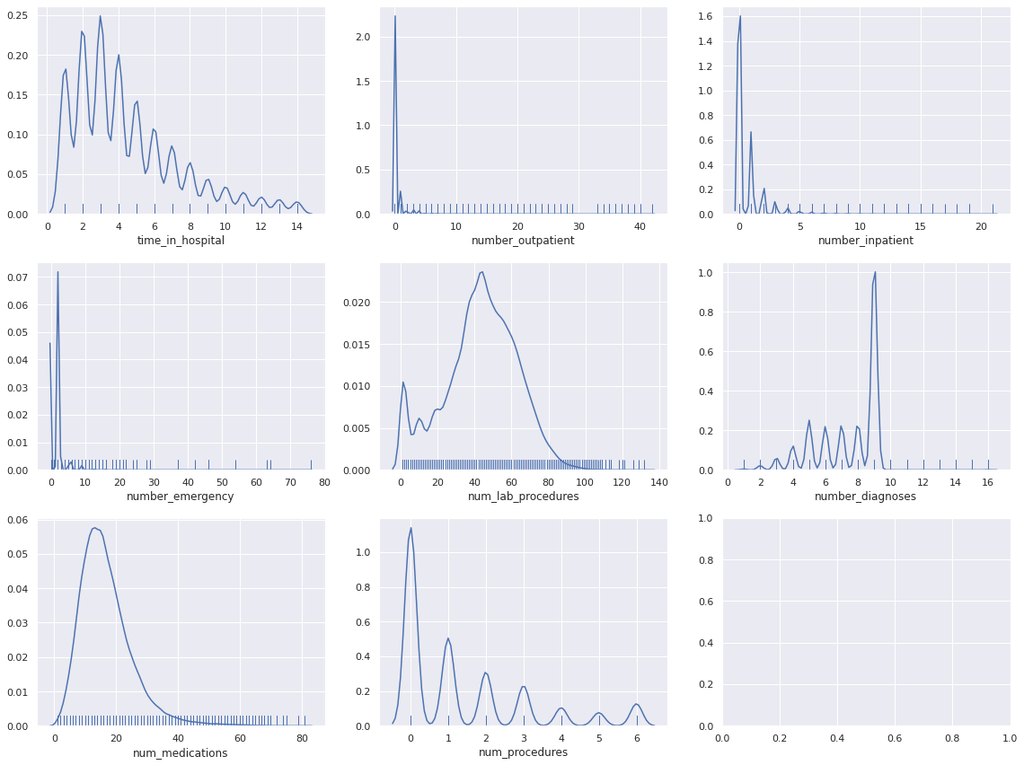

```python
num_cols = df.select_dtypes(include=['int', 'float']).columns.to_list()
# skip identifier columns
for col in ['encounter_id', 'patient_nbr']:
    num_cols.remove(col)

fig,axes = plt.subplots(ncols=3, nrows=3)
for col, ax in zip(num_cols, axes.flat):
    sns.distplot(df_msno[col], rug=True, hist=False, ax=ax)
plt.tight_layout()
plt.show()
```

The features with distribution curves close to that of a normal distribution are `num_medications` and `num_lab_procedures`. These features we will use for our model.

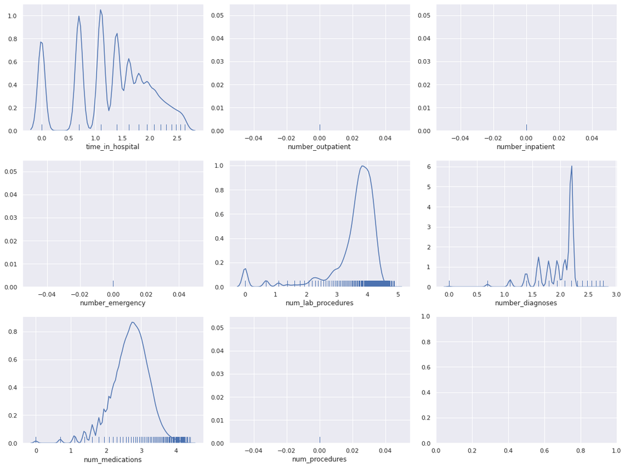

```python
fig,axes = plt.subplots(ncols=3, nrows=3)
for col, ax in zip(num_cols, axes.flat):
    sns.distplot(np.log(df_msno[col]), rug=True, hist=False, ax=ax)
plt.tight_layout()
plt.show()
```

Next, looking at correlations, we want to pick variables that are highly correlated with the target (these make good features), but the variables themselves should be uncorrelated. If two features are correlated, the model really only needs one of them as the other does not bring additional ifnromation.

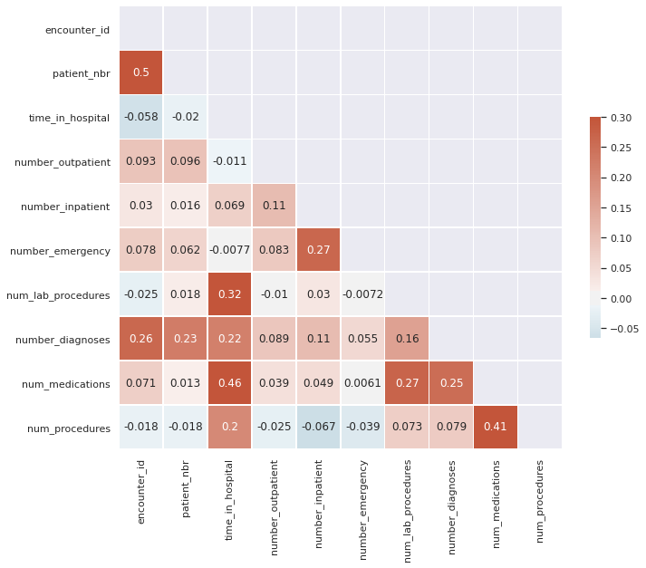

```python
corr = df_msno.corr()

# Generate a mask for the upper triangle
mask = np.triu(np.ones_like(corr, dtype=bool))

f, ax = plt.subplots(figsize=(11, 9))
cmap = sns.diverging_palette(230, 20, as_cmap=True)
sns.heatmap(corr, mask=mask, cmap=cmap, vmax=.3, center=0,
            square=True, linewidths=.5, cbar_kws={"shrink": .5}, annot=True)
```

We see that out of all numeric variables, `num_medications` (0.46) and `num_lab_procedures` (0.32) are most correlated with our target variable. That's good, we want that.

```python
cat_cols = df.select_dtypes(include=['category', 'object']).columns.to_list()
df[cat_cols].apply(pd.Series.nunique).sort_values(ascending=False)
```

```
other_diagnosis_codes       19374
primary_diagnosis_code        717
ndc_code                      251
medical_specialty              73
discharge_disposition_id       26
payer_code                     18
admission_source_id            17
weight                         10
age                            10
admission_type_id               8
race                            6
A1Cresult                       4
max_glu_serum                   4
readmitted                      3
gender                          3
change                          2
dtype: int64
```

- `other_diagnosis_codes`: exclude, very high cardinality which wouldn't be helpful for the training process

```python
# skip columns with high cardinality
for col in ['other_diagnosis_codes']:
    cat_cols.remove(col)

# skip columns with many missing values:
for col in ['weight', 'max_glu_serum', 'A1Cresult', 'medical_specialty', 'payer_code']:
    cat_cols.remove(col)
```

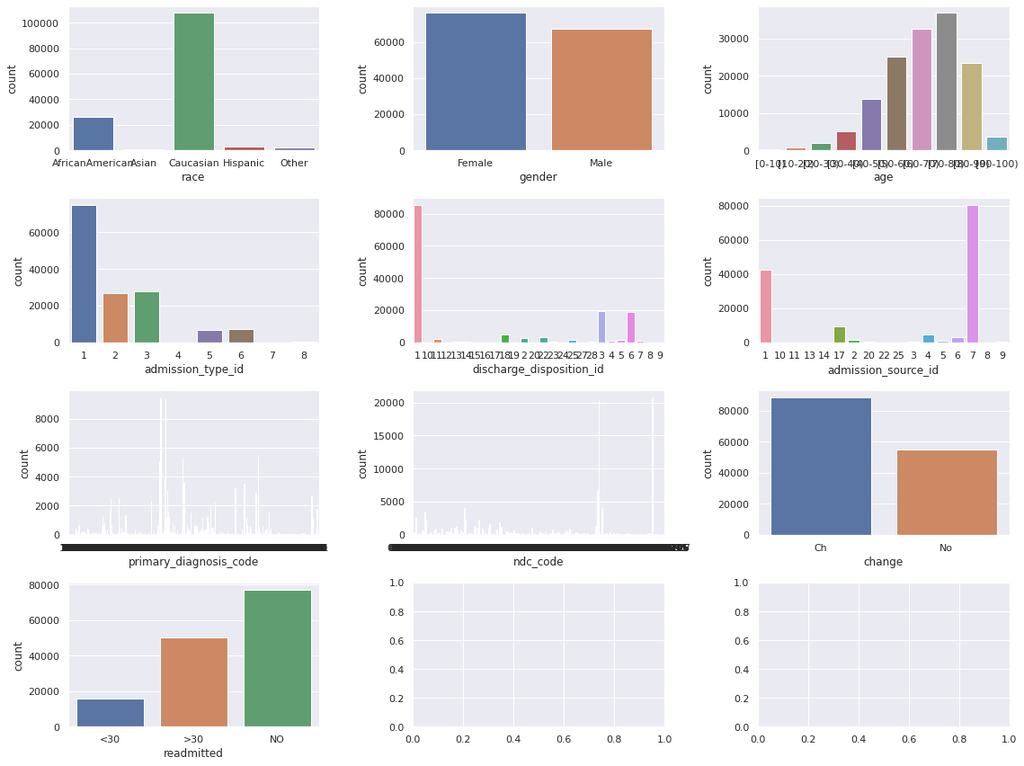

```python
fig, axes = plt.subplots(ncols=3, nrows=4)
for col, ax in zip(cat_cols, axes.flat):
    sns.countplot(x=col, data=df_msno, order=df_msno[col].value_counts().sort_index().index, ax=ax)
plt.tight_layout()
plt.show()
```

Recall that we decided:

- `weight`: exclude, 97% missing values
- `max_glu_serum`: exclude, 95.1% missing values
- `A1Cresult`: exclude, 82% missing values
- `medical_specialty`: exclude, 48.4% missing values
- `payer_code`: exclude, 37.8% missing values

First of all, let's think from a context perspective. This dataset was not created for the purpose of this project, so naturally, not all features are actually available at or during the encounter. To predict time at hospital, the model cannot make use of features that are only determined at the end of the encounter, such as `discharge_disposition_id` (Integer identifier corresponding to 29 distinct values, for example, discharged to home, expired, and not available). We will therefore not include this variable.

`ndc_code` will not be used, as we use one-hot encoding of generic drugs instead.

We could do feature selection on our categorical data based on selecting the "best" features that contribute most to a model – unfortunately, below code times out in the Udacity student workspace, so we won't make use of that for now.

```python
%%capture
# from https://machinelearningmastery.com/feature-selection-with-categorical-data/
'''
from sklearn.model_selection import train_test_split
from sklearn.preprocessing import LabelEncoder
from sklearn.preprocessing import OrdinalEncoder
from sklearn.feature_selection import SelectKBest
from sklearn.feature_selection import mutual_info_classif
from matplotlib import pyplot

# prepare input data
def prepare_inputs(X_train, X_test):
    X_train_enc = pd.get_dummies(X_train)
    X_test_enc = pd.get_dummies(X_test)
    return X_train_enc, X_test_enc

# prepare target
def prepare_targets(y_train, y_test):
    le = LabelEncoder()
    le.fit(y_train)
    y_train_enc = le.transform(y_train)
    y_test_enc = le.transform(y_test)
    return y_train_enc, y_test_enc

# feature selection
def select_features(X_train, y_train, X_test):
    fs = SelectKBest(score_func=mutual_info_classif, k='all')
    fs.fit(X_train, y_train)
    X_train_fs = fs.transform(X_train)
    X_test_fs = fs.transform(X_test)
    return X_train_fs, X_test_fs, fs

X = df.drop(['time_in_hospital', 'weight', 'max_glu_serum', 'A1Cresult', 'medical_specialty', 'payer_code'], axis=1)
y = df['time_in_hospital']

# split into train and test sets
X_train, X_test, y_train, y_test = train_test_split(X, y, test_size=0.33, random_state=1, stratify=y)

# prepare input data
X_train_enc, X_test_enc = prepare_inputs(X_train, X_test)

# prepare output data
y_train_enc, y_test_enc = prepare_targets(y_train, y_test)

# feature selection
X_train_fs, X_test_fs, fs = select_features(X_train_enc, y_train_enc, X_test_enc)

# what are scores for the features
for i in range(len(fs.scores_)):
    print('Feature %d: %f' % (i, fs.scores_[i]))
# plot the scores
pyplot.bar([i for i in range(len(fs.scores_))], fs.scores_)
pyplot.show()
'''
```

```python
required_demo_col_list = ['race', 'gender', 'age']
student_categorical_col_list = [
    'admission_type_id',
    'admission_source_id',
    'primary_diagnosis_code',
    'change',
    'readmitted'] + required_demo_col_list + ndc_col_list
student_numerical_col_list = [
    'num_lab_procedures',
    'num_medications']
PREDICTOR_FIELD = 'time_in_hospital'
```

```python
def select_model_features(df, categorical_col_list, numerical_col_list, PREDICTOR_FIELD, grouping_key='patient_nbr'):
    selected_col_list = [grouping_key] + [PREDICTOR_FIELD] + categorical_col_list + numerical_col_list
    return agg_drug_df[selected_col_list]
```

```python
selected_features_df = select_model_features(agg_drug_df, student_categorical_col_list, student_numerical_col_list,
                                            PREDICTOR_FIELD)
```

### Preprocess Dataset - Casting and Imputing

```python
processed_df = preprocess_df(selected_features_df, student_categorical_col_list,
        student_numerical_col_list, PREDICTOR_FIELD, categorical_impute_value='nan', numerical_impute_value=0)
processed_df.shape
```

```
(54271, 32)
```

We will cast and impute the dataset before splitting so that we do not have to repeat these steps across the splits in the next step. For imputing, there can be deeper analysis into which features to impute and how to impute but for the sake of time, we are taking a general strategy of imputing zero for only numerical features.

If data is **missing totally at random** (whether a value is missing does not depend on any of the feature values of that item), then imputation can be appropriate. In contrast, if the chance for data to go missing for some object **depends on the value of the features of that object**, then you have a bigger problem. In that case imputation can create bias – as can any other method.

For categorical data, a common approach is to **assign a unique category**. However, this adds less variance, and having another feature in the model while encoding may result in poor model performance – needless to say that we already have this option in place here.

Another common approach is to simply **delete the row**. This results in a robust model, since it does not have a high weightage. On the other side, we risk a loss of information and data, and this method particularly works poorly if the percentage of missing values is high (say 30%), compared to the whole dataset.

**Which method to use to handle missing data has to be inspected on the feature level, as the strategy differs depending on the amount of missing values, type of missing values, and context of the feature.**

Lastly, there is another way to impute our missing values: we could **predict the missing values** using the features which do not have missing values. This method may result in better accuracy, unless a missing value is expected to have a very high variance. One can experiment with different algorithms and check which gives the best accuracy instead of sticking to a single algorithm. This method is an improvement as long as the bias from the same is smaller than the omitted variable bias, though bias can also arise when an incomplete conditioning set is used for a categorical variable.

## Split Dataset into Train, Validation, and Test Partitions

In order to prepare the data for being trained and evaluated by a deep learning model, we will split the dataset into three partitions, with the validation partition used for optimizing the model hyperparameters during training. One of the key parts is that we need to be sure that the data does not accidently leak across partitions.

Requirements for train/val/test sets:

- Approximately 60%/20%/20% train/validation/test split
- Randomly sample different patients into each data partition
- **IMPORTANT** Make sure that a patient's data is not in more than one partition, so that we can avoid possible data leakage.
- Make sure that the total number of unique patients across the splits is equal to the total number of unique patients in the original dataset
- Total number of rows in original dataset = sum of rows across all three dataset partitions

```python
d_train, d_val, d_test = patient_dataset_splitter(processed_df, 'patient_nbr')
```

```python
print(f'{len(d_train) + len(d_val) + len(d_test)} = {len(processed_df)}')
assert len(d_train) + len(d_val) + len(d_test) == len(processed_df)
print("Test passed for number of total rows equal!")
```

```
54271 = 54271
Test passed for number of total rows equal!
```

```python
print('{} = {}'.format(d_train['patient_nbr'].nunique() + d_val['patient_nbr'].nunique() + d_test['patient_nbr'].nunique(), agg_drug_df['patient_nbr'].nunique()))
assert (d_train['patient_nbr'].nunique() + d_val['patient_nbr'].nunique() + d_test['patient_nbr'].nunique()) == agg_drug_df['patient_nbr'].nunique()
print("Test passed for number of unique patients being equal!")
```

```
54271 = 54271
Test passed for number of unique patients being equal!
```

## Demographic Representation Analysis of Split

After the split, we should check to see the distribution of key features/groups and make sure that there is representative samples across the partitions. The show_group_stats_viz function in the utils.py file can be used to group and visualize different groups and dataframe partitions.

### Label Distribution Across Partitions

Below you can see the distributution of the label across your splits. Are the histogram distribution shapes similar across partitions?

```
time_in_hospital
1.0     7318
2.0     9191
3.0     9740
4.0     7417
5.0     5348
6.0     3991
7.0     3123
8.0     2311
9.0     1597
10.0    1241
11.0    1008
12.0     783
13.0     663
14.0     540
dtype: int64
AxesSubplot(0.125,0.125;0.775x0.755)
```

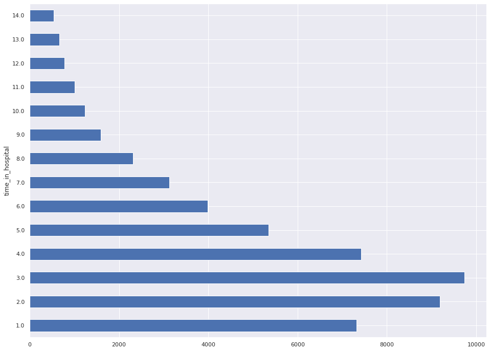

```python
show_group_stats_viz(processed_df, PREDICTOR_FIELD)
```

```
time_in_hospital
1.0     4391
2.0     5514
3.0     5844
4.0     4450
5.0     3209
6.0     2394
7.0     1874
8.0     1386
9.0      958
10.0     745
11.0     605
12.0     470
13.0     398
14.0     324
dtype: int64
AxesSubplot(0.125,0.125;0.775x0.755)
```

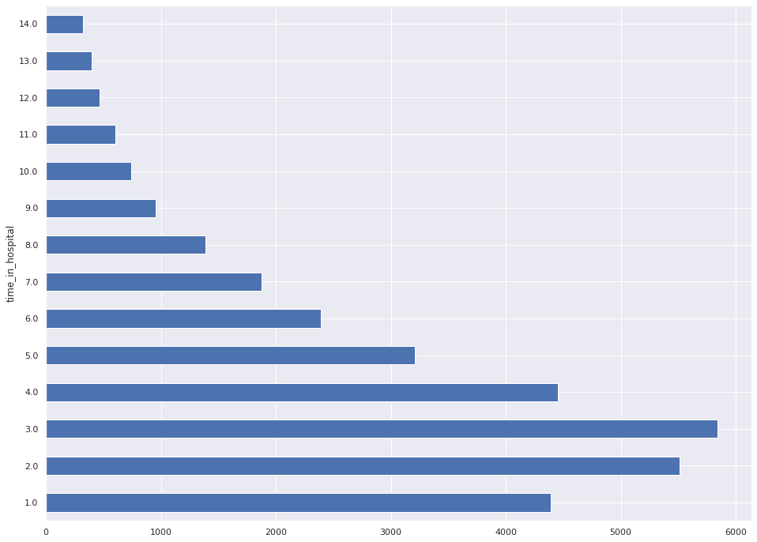

```python
show_group_stats_viz(d_train, PREDICTOR_FIELD)
```

```
time_in_hospital
1.0     1464
2.0     1839
3.0     1948
4.0     1484
5.0     1070
6.0      799
7.0      625
8.0      462
9.0      319
10.0     248
11.0     201
12.0     156
13.0     132
14.0     108
dtype: int64
AxesSubplot(0.125,0.125;0.775x0.755)
```

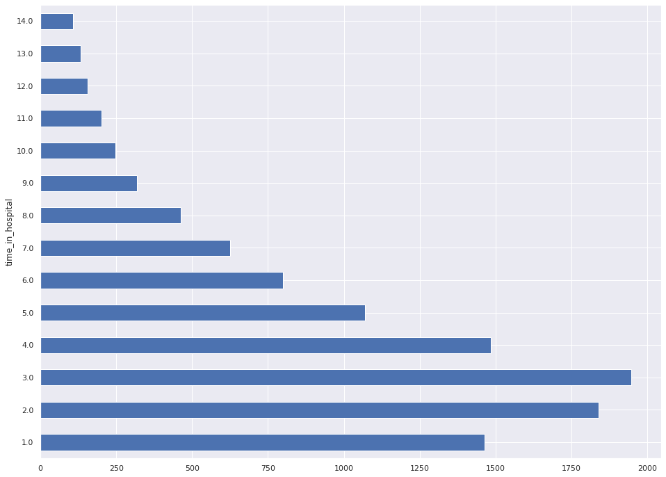

```python
show_group_stats_viz(d_test, PREDICTOR_FIELD)
```

The distribution of our predictor looks similar across train/test sets. Yay!

## Demographic Group Analysis

We should check that our partitions/splits of the dataset are similar in terms of their demographic profiles. Below you can see how we might visualize and analyze the full dataset vs. the partitions.

```
gender
Female             28572
Male               25697
Unknown/Invalid        2
dtype: int64
AxesSubplot(0.125,0.125;0.775x0.755)
```

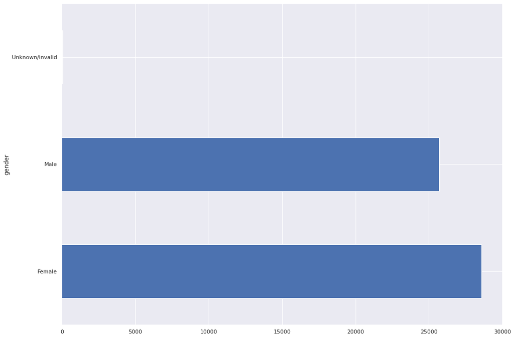

```python
# Full dataset before splitting
patient_demo_features = ['race', 'gender', 'age', 'patient_nbr']
patient_group_analysis_df = processed_df[patient_demo_features].groupby('patient_nbr').head(1).reset_index(drop=True)
show_group_stats_viz(patient_group_analysis_df, 'gender')
```

```
gender
Female             17141
Male               15420
Unknown/Invalid        1
dtype: int64
AxesSubplot(0.125,0.125;0.775x0.755)
```

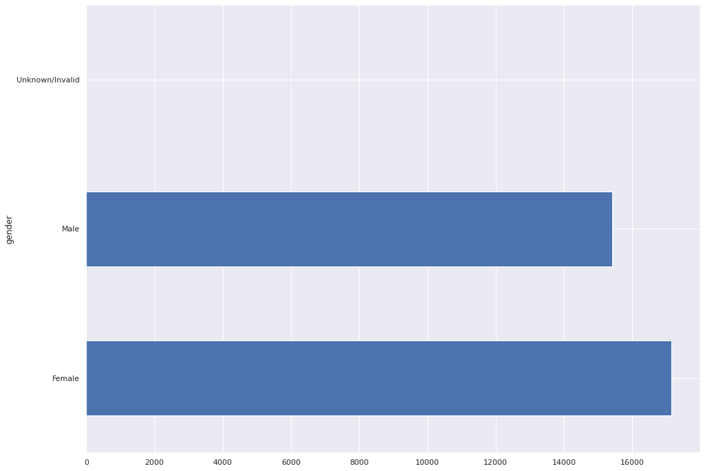

```python
# Training partition
show_group_stats_viz(d_train, 'gender')
```

```
gender
Female             5657
Male               5197
Unknown/Invalid       1
dtype: int64
AxesSubplot(0.125,0.125;0.775x0.755)
```

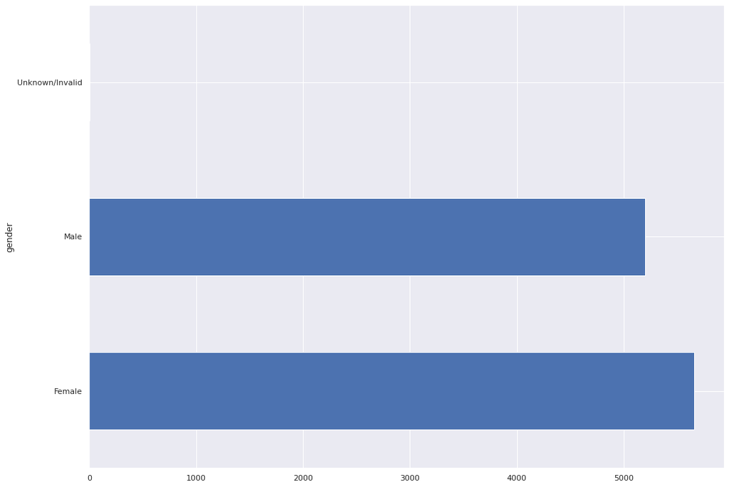

```python
# Test partition
show_group_stats_viz(d_test, 'gender')
```

The distribution of gender looks similar across train/test sets. Yay!

## Convert Dataset Splits to TF Dataset

We have provided you the function to convert the Pandas dataframe to TF tensors using the TF Dataset API. Please note that this is not a scalable method and for larger datasets, the [`make_csv_dataset`](https://www.tensorflow.org/api_docs/python/tf/data/experimental/make_csv_dataset) method is recommended.

```python
# Convert dataset from Pandas dataframes to TF dataset
batch_size = 64
diabetes_train_ds = df_to_dataset(d_train, PREDICTOR_FIELD, batch_size=batch_size)
diabetes_val_ds = df_to_dataset(d_val, PREDICTOR_FIELD, batch_size=batch_size)
diabetes_test_ds = df_to_dataset(d_test, PREDICTOR_FIELD, batch_size=batch_size)
```

```python
# We use this sample of the dataset to show transformations later
diabetes_batch = next(iter(diabetes_train_ds))[0]
def demo(feature_column, example_batch):
    feature_layer = layers.DenseFeatures(feature_column)
    print(feature_layer(example_batch))
```

# 4. Create Categorical Features with TF Feature Columns

## Build Vocabulary for Categorical Features

Before we can create the TF categorical features, we must first create the vocab files with the unique values for a given field that are from the **training** dataset. Below we have provided a function that you can use that only requires providing the pandas train dataset partition and the list of the categorical columns in a list format. The output variable 'vocab_file_list' will be a list of the file paths that can be used in the next step for creating the categorical features.

```python
vocab_file_list = build_vocab_files(d_train, student_categorical_col_list)
vocab_file_list
```

```
['./diabetes_vocab/admission_type_id_vocab.txt',
 './diabetes_vocab/admission_source_id_vocab.txt',
 './diabetes_vocab/primary_diagnosis_code_vocab.txt',
 './diabetes_vocab/change_vocab.txt',
 './diabetes_vocab/readmitted_vocab.txt',
 './diabetes_vocab/race_vocab.txt',
 './diabetes_vocab/gender_vocab.txt',
 './diabetes_vocab/age_vocab.txt',
 './diabetes_vocab/Acarbose_vocab.txt',
 './diabetes_vocab/Glimepiride_vocab.txt',
 './diabetes_vocab/Glipizide_vocab.txt',
 './diabetes_vocab/Glipizide_And_Metformin_Hcl_vocab.txt',
 './diabetes_vocab/Glipizide_And_Metformin_Hydrochloride_vocab.txt',
 './diabetes_vocab/Glyburide_vocab.txt',
 './diabetes_vocab/Glyburide_And_Metformin_Hydrochloride_vocab.txt',
 './diabetes_vocab/Glyburide-metformin_Hydrochloride_vocab.txt',
 './diabetes_vocab/Human_Insulin_vocab.txt',
 './diabetes_vocab/Insulin_Human_vocab.txt',
 './diabetes_vocab/Metformin_Hcl_vocab.txt',
 './diabetes_vocab/Metformin_Hydrochloride_vocab.txt',
 './diabetes_vocab/Miglitol_vocab.txt',
 './diabetes_vocab/Nateglinide_vocab.txt',
 './diabetes_vocab/Pioglitazone_vocab.txt',
 './diabetes_vocab/Pioglitazone_Hydrochloride_And_Glimepiride_vocab.txt',
 './diabetes_vocab/Repaglinide_vocab.txt',
 './diabetes_vocab/Rosiglitazone_Maleate_vocab.txt',
 './diabetes_vocab/Tolazamide_vocab.txt',
 './diabetes_vocab/Tolbutamide_vocab.txt']
```

## Create Categorical Features with Tensorflow Feature Column API

Using the vocab file list from above that was derived fromt the features you selected earlier, please create categorical features with the [Tensorflow Feature Column API](https://www.tensorflow.org/api_docs/python/tf/feature_column).

We will use `embedding_column` and `indicator_column` to create the categorical feature columns.

`indicator_column` creates a one-hot vector from the column values. However, when the number of categories is very large (high cardinality), the length of the sparse one-hot encoded vector can become computationally very expensive for the model. In these cases, it is better to use `embedding_columns`, which outputs a lower dimensional dense vector, thus, speeding up the model training at a lower computational expense.

```python
tf_cat_col_list = create_tf_categorical_feature_cols(student_categorical_col_list)
```

[output not shown]

[output cut: 29 more lines]

[output not shown]

```python
test_cat_var1 = tf_cat_col_list[0]
print("Example categorical field:\n{}".format(test_cat_var1))
demo(test_cat_var1, diabetes_batch)
```

```
Example categorical field:
IndicatorColumn(categorical_column=VocabularyFileCategoricalColumn(key='admission_type_id', vocabulary_file='./diabetes_vocab/admission_type_id_vocab.txt', vocabulary_size=9, num_oov_buckets=0, dtype=tf.string, default_value=-1))
WARNING:tensorflow:From /opt/conda/lib/python3.7/site-packages/tensorflow_core/python/feature_column/feature_column_v2.py:4267: IndicatorColumn._variable_shape (from tensorflow.python.feature_column.feature_column_v2) is deprecated and will be removed in a future version.
Instructions for updating:
The old _FeatureColumn APIs are being deprecated. Please use the new FeatureColumn APIs instead.
WARNING:tensorflow:From /opt/conda/lib/python3.7/site-packages/tensorflow_core/python/feature_column/feature_column_v2.py:4322: VocabularyFileCategoricalColumn._num_buckets (from tensorflow.python.feature_column.feature_column_v2) is deprecated and will be removed in a future version.
Instructions for updating:
The old _FeatureColumn APIs are being deprecated. Please use the new FeatureColumn APIs instead.
tf.Tensor(
[[0. 0. 1. 0. 0. 0. 0. 0. 0.]
 [0. 0. 1. 0. 0. 0. 0. 0. 0.]
 [0. 0. 1. 0. 0. 0. 0. 0. 0.]
 [0. 0. 1. 0. 0. 0. 0. 0. 0.]
 [0. 0. 1. 0. 0. 0. 0. 0. 0.]
 [0. 0. 1. 0. 0. 0. 0. 0. 0.]
 [0. 0. 0. 1. 0. 0. 0. 0. 0.]
 [0. 1. 0. 0. 0. 0. 0. 0. 0.]
 [0. 0. 1. 0. 0. 0. 0. 0. 0.]
 [0. 0. 1. 0. 0. 0. 0. 0. 0.]
 [0. 0. 1. 0. 0. 0. 0. 0. 0.]
 [0. 0. 1. 0. 0. 0. 0. 0. 0.]
 [0. 1. 0. 0. 0. 0. 0. 0. 0.]
 [0. 0. 1. 0. 0. 0. 0. 0. 0.]
 [0. 0. 1. 0. 0. 0. 0. 0. 0.]
 [0. 0. 1. 0. 0. 0. 0. 0. 0.]
 [0. 0. 0. 1. 0. 0. 0. 0. 0.]
 [0. 0. 0. 1. 0. 0. 0. 0. 0.]
 [0. 1. 0. 0. 0. 0. 0. 0. 0.]
 [0. 0. 0. 1. 0. 0. 0. 0. 0.]
 [0. 0. 1. 0. 0. 0. 0. 0. 0.]
 [0. 0. 1. 0. 0. 0. 0. 0. 0.]
 [0. 0. 0. 1. 0. 0. 0. 0. 0.]
 [0. 0. 1. 0. 0. 0. 0. 0. 0.]
 [0. 0. 1. 0. 0. 0. 0. 0. 0.]
 [0. 0. 0. 0. 0. 1. 0. 0. 0.]
 [0. 0. 1. 0. 0. 0. 0. 0. 0.]
 [0. 0. 1. 0. 0. 0. 0. 0. 0.]
 [0. 0. 0. 1. 0. 0. 0. 0. 0.]
 [0. 0. 1. 0. 0. 0. 0. 0. 0.]
 [0. 0. 1. 0. 0. 0. 0. 0. 0.]
```

[output cut: 18 more lines]

```
 [0. 0. 1. 0. 0. 0. 0. 0. 0.]
 [0. 0. 0. 0. 1. 0. 0. 0. 0.]
 [0. 0. 0. 1. 0. 0. 0. 0. 0.]
 [0. 0. 1. 0. 0. 0. 0. 0. 0.]
 [0. 0. 1. 0. 0. 0. 0. 0. 0.]
 [0. 1. 0. 0. 0. 0. 0. 0. 0.]
 [0. 1. 0. 0. 0. 0. 0. 0. 0.]
 [0. 1. 0. 0. 0. 0. 0. 0. 0.]
 [0. 0. 1. 0. 0. 0. 0. 0. 0.]
 [0. 1. 0. 0. 0. 0. 0. 0. 0.]
 [0. 0. 1. 0. 0. 0. 0. 0. 0.]
 [0. 0. 1. 0. 0. 0. 0. 0. 0.]
 [0. 0. 1. 0. 0. 0. 0. 0. 0.]
 [0. 0. 1. 0. 0. 0. 0. 0. 0.]
 [0. 0. 0. 1. 0. 0. 0. 0. 0.]], shape=(64, 9), dtype=float32)
```

# 5. Create Numerical Features with TF Feature Columns

Using the TF Feature Column API(https://www.tensorflow.org/api_docs/python/tf/feature_column/), please create normalized Tensorflow numeric features for the model. Use the z-score normalizer function below to help as well as the 'calculate_stats_from_train_data' function.

For simplicity the create_tf_numerical_feature_cols function below uses the same normalizer function across all features(z-score normalization) but if you have time feel free to analyze and adapt the normalizer based off the statistical distributions. You may find this as a good resource in determining which transformation fits best for the data https://developers.google.com/machine-learning/data-prep/transform/normalization.

```python
tf_cont_col_list = create_tf_numerical_feature_cols(student_numerical_col_list, d_train)
```

```
num_lab_procedures 	- mean: 43.56283397825686 - std: 20.19801391298941, numeric (normalized)

num_medications 	- mean: 16.582396658681898 - std: 8.478063817845873, numeric (normalized)
```

```python
test_cont_var1 = tf_cont_col_list[0]
print("Example continuous field:\n{}\n".format(test_cont_var1))
demo(test_cont_var1, diabetes_batch)
```

```
Example continuous field:
NumericColumn(key='num_lab_procedures', shape=(1,), default_value=(0,), dtype=tf.float64, normalizer_fn=functools.partial(<function normalize_numeric_with_zscore at 0x7f18f5317dd0>, mean=43.56283397825686, std=20.19801391298941))

tf.Tensor(
[[-0.3 ]
 [ 1.85]
 [ 0.9 ]
 [-0.2 ]
 [ 0.6 ]
 [ 0.85]
 [-1.9 ]
 [-0.45]
 [-0.8 ]
 [ 1.4 ]
 [ 0.5 ]
 [-0.05]
 [-2.05]
 [-0.1 ]
 [ 0.1 ]
 [ 1.5 ]
 [ 0.25]
 [-1.9 ]
 [-0.4 ]
 [ 1.25]
 [-0.45]
 [ 1.85]
 [-0.15]
 [ 1.1 ]
 [ 0.15]
 [ 1.45]
 [-0.9 ]
 [ 0.05]
 [ 0.65]
 [ 1.6 ]
 [ 1.6 ]
 [ 0.55]
 [ 0.5 ]
 [ 0.05]
 [ 2.3 ]
 [-1.25]
```

[output cut: 13 more lines]

```
 [ 1.25]
 [-0.85]
 [ 1.5 ]
 [ 0.4 ]
 [ 0.7 ]
 [-0.1 ]
 [-1.15]
 [ 0.6 ]
 [ 0.75]
 [ 1.  ]
 [ 0.45]
 [ 0.1 ]
 [ 1.3 ]
 [ 1.15]
 [ 0.5 ]], shape=(64, 1), dtype=float32)
```

# 6. Build Deep Learning Regression Model with Sequential API and TF Probability Layers

## Use DenseFeatures to combine features for model

Now that we have prepared categorical and numerical features using Tensorflow's Feature Column API, we can combine them into a dense vector representation for the model. Below we will create this new input layer, which we will call 'claim_feature_layer'.

```python
claim_feature_columns = tf_cat_col_list + tf_cont_col_list
claim_feature_layer = tf.keras.layers.DenseFeatures(claim_feature_columns)
```

## Build Sequential API Model from DenseFeatures and TF Probability Layers

```python
def build_baseline_model(train_ds, val_ds,  feature_layer,  epochs=5, loss_metric='mse', patience=3):
    model = tf.keras.Sequential([
        feature_layer,
        tf.keras.layers.Dense(150, activation='relu'),
        tf.keras.layers.Dense(75, activation='relu'),
        tfp.layers.DenseVariational(1+1, posterior_mean_field, prior_trainable),
        tfp.layers.DistributionLambda(
            lambda t:tfp.distributions.Normal(loc=t[..., :1],
                                             scale=1e-3 + tf.math.softplus(0.01 * t[...,1:])
                                             )
        ),
    ])
    model.compile(optimizer='rmsprop', loss=loss_metric, metrics=[loss_metric])
    early_stop = tf.keras.callbacks.EarlyStopping(monitor=loss_metric, patience=patience)
    history = model.fit(train_ds, validation_data=val_ds,
                        callbacks=[early_stop],
                        epochs=epochs)
    return model, history

def load_baseline_model(feature_layer, checkpoint_path, loss_metric='mse'):
    model = tf.keras.Sequential([
        feature_layer,
        tf.keras.layers.Dense(150, activation='relu'),
        tf.keras.layers.Dense(75, activation='relu'),
        tfp.layers.DenseVariational(1+1, posterior_mean_field, prior_trainable),
        tfp.layers.DistributionLambda(
            lambda t:tfp.distributions.Normal(loc=t[..., :1],
                                             scale=1e-3 + tf.math.softplus(0.01 * t[...,1:])
                                             )
        ),
    ])
    model.compile(optimizer='rmsprop', loss=loss_metric, metrics=[loss_metric])
    model.load_weights(checkpoint_path)
    return model
```

```python
def build_compile(model_choice, feature_layer, loss_metric, lr_i=1e-2):
    model = model_choice(feature_layer)
    lr_schedule = tf.keras.optimizers.schedules.ExponentialDecay(
        initial_learning_rate=lr_i,
        decay_steps=10000,
        decay_rate=0.95,
        staircase=True
    )
    optimizer = tf.keras.optimizers.Adam(learning_rate=lr_schedule)
    model.compile(optimizer=optimizer, loss=loss_metric, metrics=[loss_metric])
    return model

def build_diabetes_model(model_choice, train_ds, val_ds,  feature_layer,  epochs=5, loss_metric='mse', lr_i=1e-2):
    model = build_compile(model_choice, feature_layer, loss_metric, lr_i)

    checkpoint = ModelCheckpoint(weight_path,
                             monitor=loss_metric,
                             verbose=1,
                             save_best_only=True,
                             mode='min',
                             save_weights_only = True)

    early_stop = EarlyStopping(monitor=loss_metric,
                               patience=10)

    callbacks_list = [checkpoint,
                      early_stop]

    history = model.fit(train_ds,
                        validation_data=val_ds,
                        callbacks=callbacks_list,
                        epochs=epochs, verbose=1)

    return model, history

def load_model(model_choice, feature_layer, checkpoint_path, loss_metric='mse', lr_i=1e-2):
    model = build_compile(model_choice, feature_layer, loss_metric, lr_i)
    model.load_weights(checkpoint_path)
    return model

def plot_history(history, model_name):
    f = plt.figure()
    f.set_figwidth(10)

    plt.plot(history.history['val_loss'], label='val loss')
    plt.plot(history.history['loss'], label='train loss')
    plt.legend();
    plt.savefig('{}-history-plot.png'.format(model_name))
```

## Baseline model

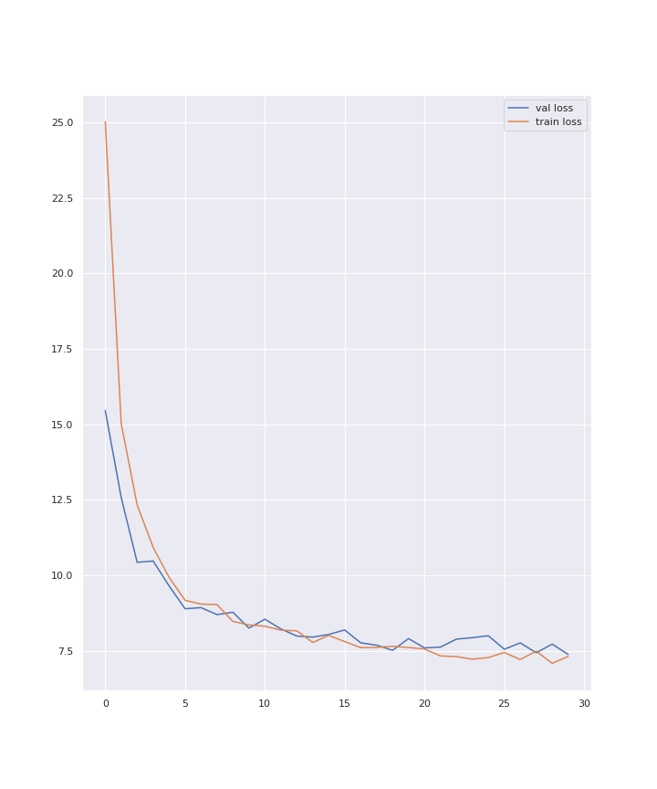

```
CPU times: user 94.6 ms, sys: 3.95 ms, total: 98.5 ms
Wall time: 102 ms
```

```python
%%time

train = False

model_name = 'baseline'
weight_path = "weights/{}_cp.ckpt".format(model_name)

if train:
    baseline_model, history = build_baseline_model(diabetes_train_ds, diabetes_val_ds,  claim_feature_layer, epochs=30)
    plot_history(history, model_name)
else:
    baseline_model, history = load_baseline_model(claim_feature_layer, weight_path), None
    image_path = '{}-history-plot.png'.format(model_name)
    display.display(Image.open(image_path))
```

## Try other models

```python
def build_sequential_3rd_model(feature_layer):
    model = tf.keras.Sequential([
        feature_layer,
        tf.keras.layers.Dense(128, activation='relu',
                              kernel_regularizer=tf.keras.regularizers.l1(0.01),
                              activity_regularizer=tf.keras.regularizers.l2(0.01)),
        tf.keras.layers.Dropout(0.5),
        tf.keras.layers.Dense(64, activation='relu'),
        tf.keras.layers.Dropout(0.5),
        tf.keras.layers.Dense(32, activation='relu'),
        tfp.layers.DenseVariational(1+1, posterior_mean_field, prior_trainable),
        tfp.layers.DistributionLambda(
            lambda t:tfp.distributions.Normal(loc=t[..., :1],
                                             scale=1e-3 + tf.math.softplus(0.01 * t[...,1:])
                                             )
        ),
    ])
    return model
```

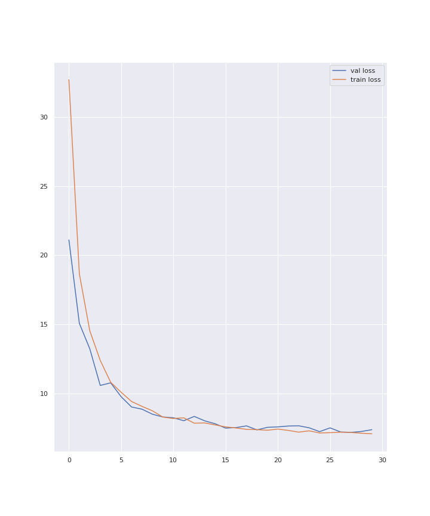

```
CPU times: user 91.6 ms, sys: 3.99 ms, total: 95.6 ms
Wall time: 99.1 ms
```

```python
%%time

train = False

model_name = 'sequential_3rd'
weight_path = "weights/{}_cp.ckpt".format(model_name)

if train:
    sequential_3rd_model, history = build_diabetes_model(build_sequential_3rd_model,
                                                        diabetes_train_ds,
                                                        diabetes_val_ds,
                                                        claim_feature_layer,
                                                        epochs=30,
                                                        lr_i=1e-3)
    plot_history(history, model_name)
else:
    sequential_3rd_model, history = load_model(build_sequential_3rd_model, claim_feature_layer, weight_path), None
    image_path = '{}-history-plot.png'.format(model_name)
    display.display(Image.open(image_path))
```

```python
def build_sequential_4rd_model(feature_layer):
    model = tf.keras.Sequential([
        feature_layer,
        tf.keras.layers.Dense(256, activation='relu',
                              kernel_regularizer=tf.keras.regularizers.l1(0.01),
                              activity_regularizer=tf.keras.regularizers.l2(0.01)),
        tf.keras.layers.Dense(128, activation='relu'),
        tf.keras.layers.Dropout(0.5),
        tf.keras.layers.Dense(64, activation='relu'),
        tf.keras.layers.Dropout(0.5),
        tf.keras.layers.Dense(32, activation='relu'),
        tfp.layers.DenseVariational(1+1, posterior_mean_field, prior_trainable),
        tfp.layers.DistributionLambda(
            lambda t:tfp.distributions.Normal(loc=t[..., :1],
                                             scale=1e-3 + tf.math.softplus(0.01 * t[...,1:])
                                             )
        ),
    ])
    return model
```

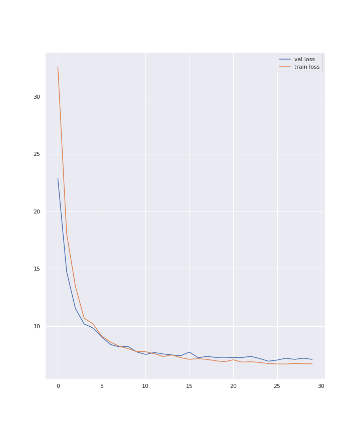

```
CPU times: user 99.8 ms, sys: 0 ns, total: 99.8 ms
Wall time: 103 ms
```

```python
%%time

train = False

model_name = 'sequential_4rd'
weight_path = "weights/{}_cp.ckpt".format(model_name)

if train:
    sequential_4rd_model, history = build_diabetes_model(build_sequential_4rd_model,
                                                        diabetes_train_ds,
                                                        diabetes_val_ds,
                                                        claim_feature_layer,
                                                        epochs=30,
                                                        lr_i=1e-3)
    plot_history(history, model_name)
else:
    sequential_4rd_model, history = load_model(build_sequential_4rd_model, claim_feature_layer, weight_path), None
    image_path = '{}-history-plot.png'.format(model_name)
    display.display(Image.open(image_path))
```

```python
def build_sequential_5d_model(feature_layer):
    model = tf.keras.Sequential([
        feature_layer,
        tf.keras.layers.Dense(512, activation='relu'),
        tf.keras.layers.Dropout(0.5),
        tf.keras.layers.Dense(256, activation='relu'),
        tf.keras.layers.Dropout(0.5),
        tf.keras.layers.Dense(128, activation='relu'),
        tf.keras.layers.Dropout(0.5),
        tf.keras.layers.Dense(64, activation='relu'),
        tf.keras.layers.Dropout(0.5),
        tf.keras.layers.Dense(32, activation='relu'),
        tfp.layers.DenseVariational(1+1, posterior_mean_field, prior_trainable),
        tfp.layers.DistributionLambda(
            lambda t:tfp.distributions.Normal(loc=t[..., :1],
                                             scale=1e-3 + tf.math.softplus(0.01 * t[...,1:])
                                             )
        ),
    ])
    return model
```

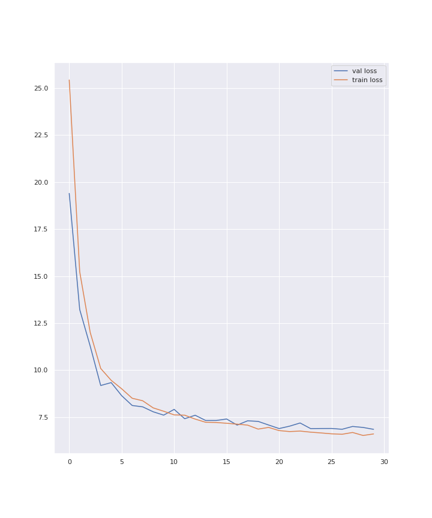

```
CPU times: user 100 ms, sys: 0 ns, total: 100 ms
Wall time: 104 ms
```

```python
%%time

train = False

model_name = 'sequential_5d'
weight_path = "weights/{}_cp.ckpt".format(model_name)

if train:
    sequential_5d_model, history = build_diabetes_model(build_sequential_5d_model,
                                                        diabetes_train_ds,
                                                        diabetes_val_ds,
                                                        claim_feature_layer,
                                                        epochs=30,
                                                        lr_i=1e-3)
    plot_history(history, model_name)
else:
    sequential_5d_model, history = load_model(build_sequential_5d_model, claim_feature_layer, weight_path), None
    image_path = '{}-history-plot.png'.format(model_name)
    display.display(Image.open(image_path))
```

```python
def build_sequential_6r_model(feature_layer):
    model = tf.keras.Sequential([
        feature_layer,
        tf.keras.layers.Dense(1024, activation='relu',
                              kernel_regularizer=tf.keras.regularizers.l1(0.01),
                              activity_regularizer=tf.keras.regularizers.l2(0.01)),
        tf.keras.layers.Dense(512, activation='relu'),
        tf.keras.layers.Dense(256, activation='relu'),
        tf.keras.layers.Dense(128, activation='relu'),
        tf.keras.layers.Dense(64, activation='relu'),
        tf.keras.layers.Dense(32, activation='relu'),
        tfp.layers.DenseVariational(1+1, posterior_mean_field, prior_trainable),
        tfp.layers.DistributionLambda(
            lambda t:tfp.distributions.Normal(loc=t[..., :1],
                                             scale=1e-3 + tf.math.softplus(0.01 * t[...,1:])
                                             )
        ),
    ])
    return model
```

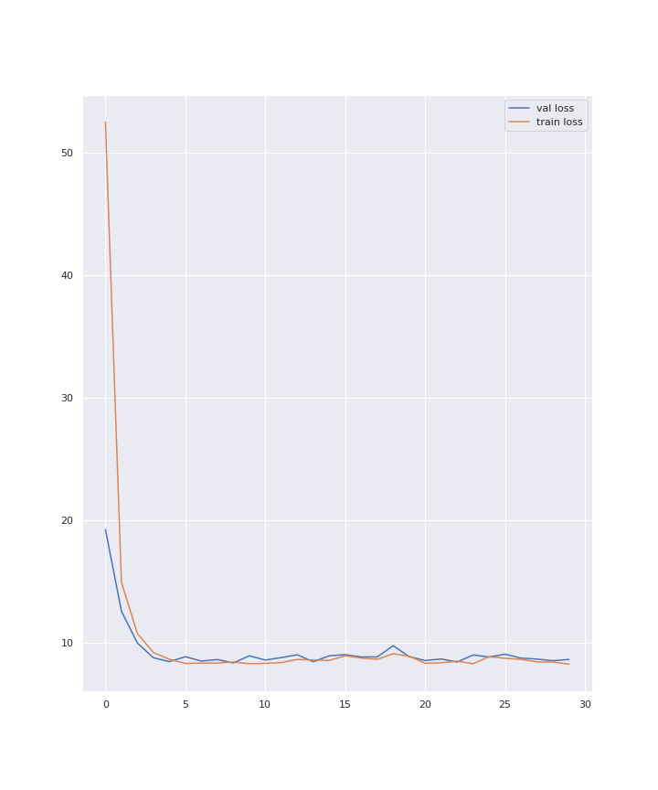

```
CPU times: user 95.7 ms, sys: 3.71 ms, total: 99.4 ms
Wall time: 103 ms
```

```python
%%time

train = False

model_name = 'sequential_6r'
weight_path = "weights/{}_cp.ckpt".format(model_name)

if train:
    sequential_6r_model, history = build_diabetes_model(build_sequential_6r_model,
                                                        diabetes_train_ds,
                                                        diabetes_val_ds,
                                                        claim_feature_layer,
                                                        epochs=30)
    plot_history(history, model_name)
else:
    sequential_6r_model, history = load_model(build_sequential_6r_model, claim_feature_layer, weight_path), None
    image_path = '{}-history-plot.png'.format(model_name)
    display.display(Image.open(image_path))
```

## Pick Model & Model Evaluation Metrics

```python
def get_model_performance(student_categorical_col_list,
                          student_numerical_col_list,
                          d_test,
                          diabetes_test_ds,
                          diabetes_model,
                          model_name):

    # Now that we have trained a model with TF Probability layers,
    # we can extract the mean and standard deviation for each prediction.
    feature_list = student_categorical_col_list + student_numerical_col_list
    diabetes_x_tst = dict(d_test[feature_list])
    diabetes_yhat = diabetes_model(diabetes_x_tst)
    preds = diabetes_model.predict(diabetes_test_ds)
    m, s = get_mean_std_from_preds(diabetes_yhat)

    # prediction output
    prob_outputs = {
        "pred": preds.flatten(),
        "actual_value": d_test['time_in_hospital'].values,
        "pred_mean": m.numpy().flatten(),
        "pred_std": s.numpy().flatten()
    }
    prob_output_df = pd.DataFrame(prob_outputs)

    # Convert Regression Output to Classification Output for Patient Selection
    # Given the output predictions, convert it to a binary label for whether the patient meets the time criteria or does not
    # (HINT: use the mean prediction numpy array).
    # The expected output is a numpy array with a 1 or 0 based off if the prediction meets or doesnt meet the criteria.
    student_binary_prediction = get_student_binary_prediction(prob_output_df, 'pred_mean')

    # Add Binary Prediction to Test Dataframe
    # Using the student_binary_prediction output that is a numpy array with binary labels,
    # we can use this to add to a dataframe to better visualize and also to prepare the data for the Aequitas toolkit.
    # The Aequitas toolkit requires that the predictions be mapped to a binary label for the predictions
    # (called 'score' field) and the actual value (called 'label_value').
    pred_test_df = add_pred_to_test(d_test, student_binary_prediction, ['race', 'gender'])

    y_val = pred_test_df['label_value']
    y_pred = pred_test_df['score']

    # get metrics
    f1, class_report, auc, precision, recall = get_metrics(y_val, y_pred)
    tn, fp, fn, tp = confusion_matrix(y_val, y_pred).ravel()

    plot_auc(y_val, y_pred, model_name)
    plot_pr(y_val, y_pred, model_name)

    print("AUC: \t\t", auc)
    print("F1: \t\t", f1)
    print("Precision: \t", precision)
    print("Recall: \t", recall)
    print(f"\nTN: {tn}, FP: {fp}, FN: {fn}, TP: {tp}")
    print(class_report)

    return auc, f1, precision, recall, tn, fp, fn, tp, class_report, pred_test_df
```

We built a regression model that predicts the expected days of hospitalization time and then converted this to a binary prediction of whether to include or exclude that patient from the clinical trial. The threshold was set to time in hospital being bigger or equal to 5 days.

Here is an explanation of our metrics:

Possible scenarios:

- **Low recall, low precision**: Our model straight up sucks :)
- **High recall, low precision**: Our model includes a lot of patients, both patients that should be included but also those that should not be included.
- **Low recall, high precision**: Our model is very picky. All patients that it labels as to include, should really be included. But because it is picky, it misses many other patients that should be included.
- **High recall, high precision**: Ideal scenario!

Precision-recall trade-off: When we change the threshold for determining if a class is positive or negative, this action will "tilt the scales". It will either cause precision to increase and recall to decrease or vice versa. This means, If we increase precision, it will reduce recall, if we increase recall, it will reduce precision. We can never increase both, so this is what the precision-recall trade-off is about.

In the ROC curve, we plot sensitivity against (1-)specificity for different rheshold values. Each point onn the ROC represents a separate confusion matrix. AUC is the probability of correct ranking of a random positive-negative pair. A good ROC curve pushes towards the top-left side.

F1 score is the weighted average of precision and recall. This score takes both FP and FN into account. Accuracy works best if FP and FN have similar cost, but since the cost is different for us in a medical setting, it is better to look at both precision and recall. The score ranges between 0 and 1, with 1 being the best.

### Baseline performance

Let's get a benchmark with our baseline model, and see if we were able to improve something:

```python
diabetes_model = baseline_model
model_name = 'baseline'
```

```
(10855,)
<class 'numpy.ndarray'>
```

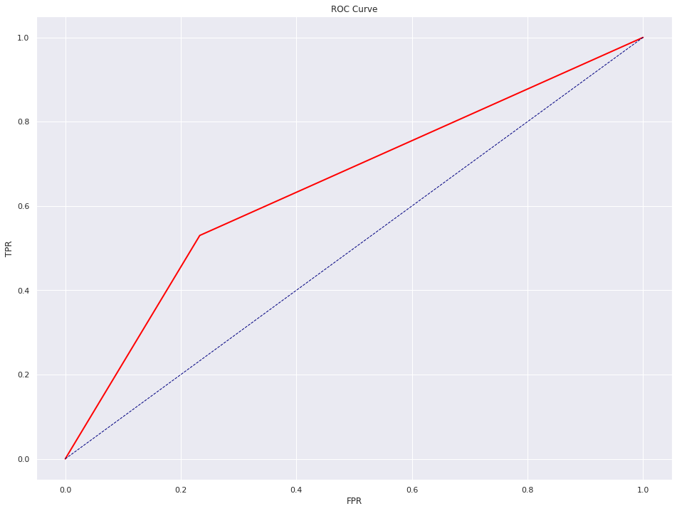

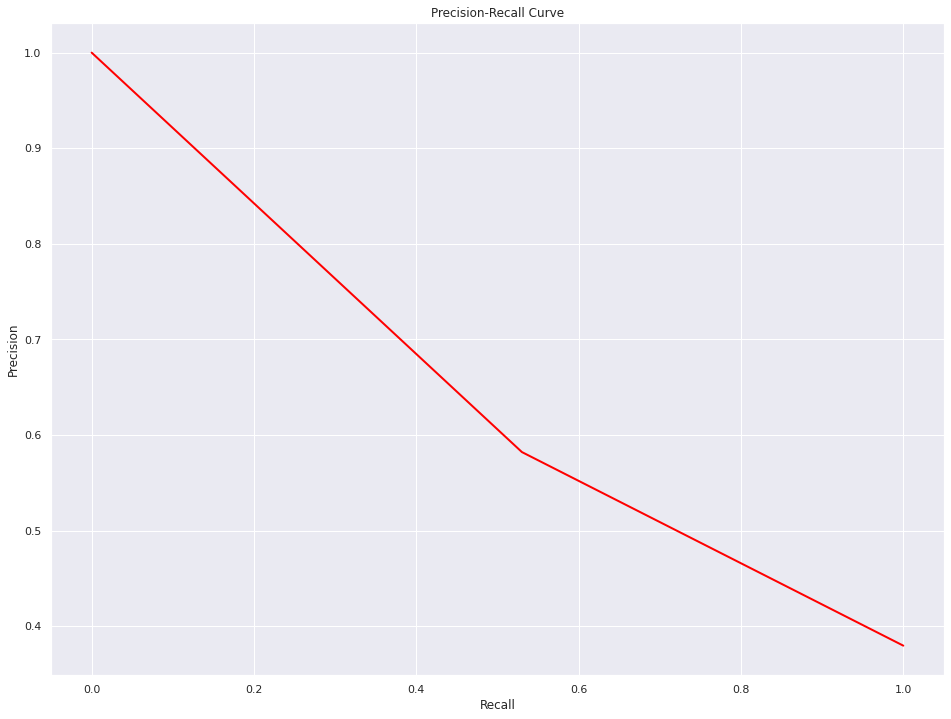

```
AUC: 		 0.6486417136967443
F1: 		 0.6739465006889984
Precision: 	 0.6771994472593275
Recall: 	 0.6771994472593275

TN: 5167, FP: 1568, FN: 1936, TP: 2184
              precision    recall  f1-score   support

           0       0.73      0.77      0.75      6735
           1       0.58      0.53      0.55      4120

    accuracy                           0.68     10855
   macro avg       0.65      0.65      0.65     10855
weighted avg       0.67      0.68      0.67     10855
```

```python
auc, f1, precision, recall, tn, fp, fn, tp, class_report, pred_test_df = get_model_performance(student_categorical_col_list,
                                                                                 student_numerical_col_list,
                                                                                 d_test,
                                                                                 diabetes_test_ds,
                                                                                 diabetes_model,
                                                                                 model_name)
```

### Pick Model & Picked Model Performance

```python
diabetes_model = sequential_6r_model
model_name = 'sequential_6r'
```

```
(10855,)
<class 'numpy.ndarray'>
```

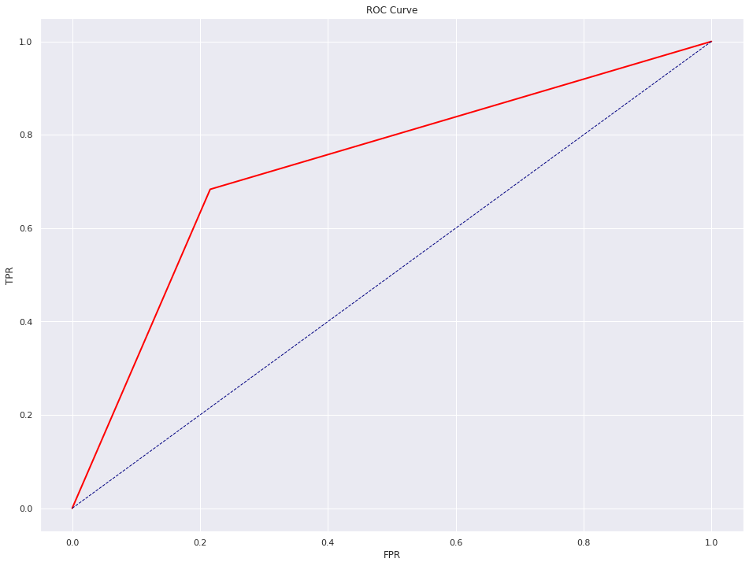

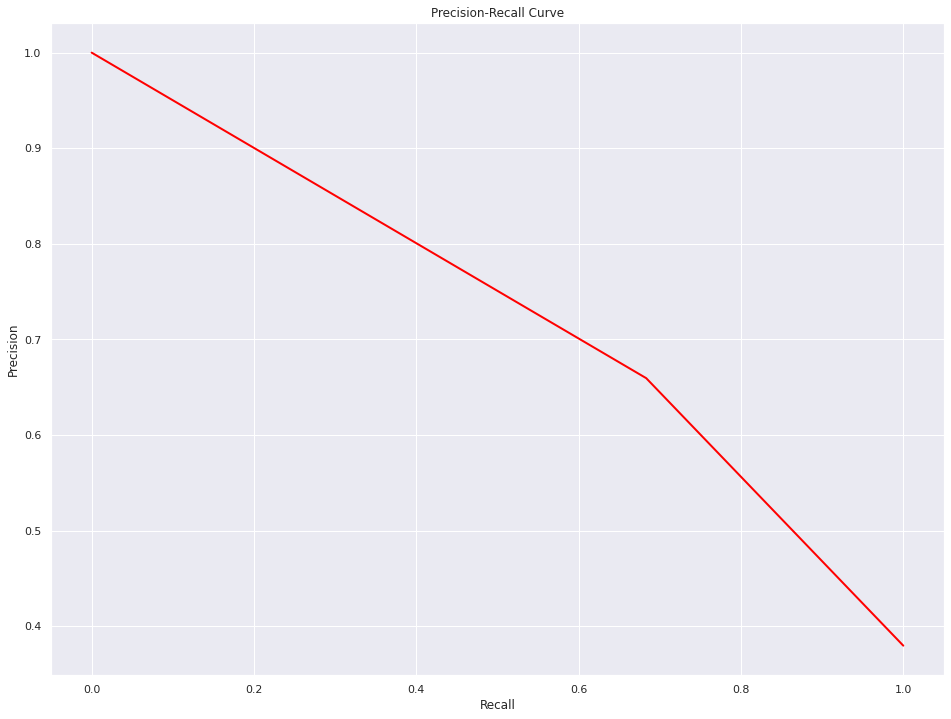

```
AUC: 		 0.7336826352700355
F1: 		 0.746667121385009
Precision: 	 0.7458314140948872
Recall: 	 0.7458314140948872

TN: 5281, FP: 1454, FN: 1305, TP: 2815
              precision    recall  f1-score   support

           0       0.80      0.78      0.79      6735
           1       0.66      0.68      0.67      4120

    accuracy                           0.75     10855
   macro avg       0.73      0.73      0.73     10855
weighted avg       0.75      0.75      0.75     10855
```

```python
auc, f1, precision, recall, tn, fp, fn, tp, class_report, pred_test_df = get_model_performance(student_categorical_col_list,
                                                                                 student_numerical_col_list,
                                                                                 d_test,
                                                                                 diabetes_test_ds,
                                                                                 diabetes_model,
                                                                                 model_name)
```

We reach an F1-score of 0.7467, with an AUC of 0.7337, and precision and recall of 0.7458. Our model has learnt something, and also outperformed our baseline model. Let's call that a success :)

We've done a bit of model fine-tuning, and of course we will likely be able to yield better performance if we experimented some more with hyperparameters and architecture, or even choose to use a different model altogether. However, my first suggestion would be to go back to feature engineering and take a deep dive there, as good features really make and break any model.

# 7. Evaluating Potential Model Biases with Aequitas Toolkit

## Prepare Data For Aequitas Bias Toolkit

Using the gender and race fields, we will prepare the data for the Aequitas Toolkit.

```python
ae_subset_df = pred_test_df[['race', 'gender', 'score', 'label_value']]
ae_df, _ = preprocess_input_df(ae_subset_df)
g = Group()
xtab, _ = g.get_crosstabs(ae_df)
absolute_metrics = g.list_absolute_metrics(xtab)
clean_xtab = xtab.fillna(-1)
aqp = Plot()
b = Bias()
```

```
model_id, score_thresholds 1 {'rank_abs': [4269]}
```

## Reference Group Selection

```python
# test reference group with Caucasian Male
bdf = b.get_disparity_predefined_groups(clean_xtab,
                    original_df=ae_df,
                    ref_groups_dict={'race':'Caucasian', 'gender':'Male'
                                     },
                    alpha=0.05,
                    check_significance=False)


f = Fairness()
fdf = f.get_group_value_fairness(bdf)
```

```
get_disparity_predefined_group()
```

## Race and Gender Bias Analysis for Patient Selection

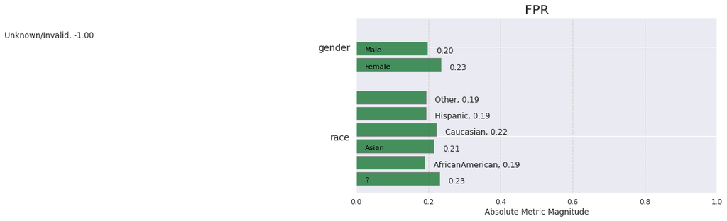

```python
fpr_fairness = aqp.plot_fairness_group(fdf, group_metric='fpr', title=True)
```

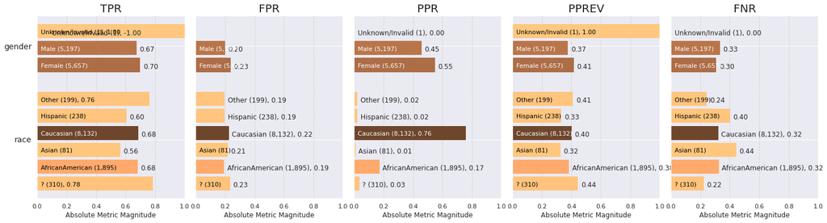

```python
p = aqp.plot_group_metric_all(clean_xtab, metrics=['tpr', 'fpr', 'ppr', 'pprev', 'fnr'], ncols=5)
```

How do we interpret above?

- False Negative: The model predicted the patient did not stay in hospital for at least 5 days (thus not selected for drug testing), while they were.
- False Positive: The model predicted the patient stayed in hospital for at least 5 days (thus selected for drug testing), while they were not.

Example: For FNR, the model was quite fair evaluating patients across gender. However, when a patient should be selected for drug testing, our model incorrectly recommended not selecting these patients 44% of the cases where the patient was Asian and 40% when the patient was Hispanic. There is a small bias towards these race groups compared to Caucasian (32%) and African American (32%).

## Fairness Analysis Example - Relative to a Reference Group

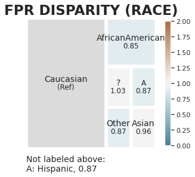

```python
fpr_disparity = aqp.plot_disparity(bdf, group_metric='fpr_disparity', attribute_name='race')
```

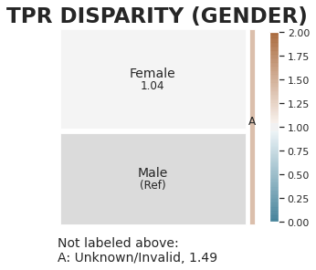

```python
tpr_disparity = aqp.plot_disparity(bdf, group_metric='tpr', attribute_name='gender')
```

For the disparity plots, we chose Caucasian and Male as the reference groups.